# The Little Typer.Friedman2018

[figure not shown]

**The Little Typer**

**The Little Typer**

Daniel P. Friedman  
David Thrane Christiansen

Drawings by Duane Bibby

Foreword by Robert Harper

Afterword by Conor McBride

The MIT Press  
Cambridge, Massachusetts  
London, England

© 2018 Massachusetts Institute of Technology

All rights reserved. With the exception of completed code examples in solid boxes, no part of this book may be reproduced in any form by any electronic or mechanical means (including photocopying, recording, or information storage and retrieval) without permission in writing from the publisher. The completed code examples that are presented in solid boxes are licensed under a Creative Commons Attribution 4.0 International License (CC-By 4.0).

This book was set in Computer Modern Unicode by the authors using .

Library of Congress Cataloging-in-Publication Data

Names: Friedman, Daniel P., author. | Christiansen, David Thrane, author.

Title: The little typer / Daniel P. Friedman and David Thrane Christiansen ; drawings by Duane Bibby ; foreword by Robert Harper ; afterword by Conor McBride.

Description: Cambridge, MA : The MIT Press, [2018] | Includes index.

Identifiers: LCCN 2018017792 | ISBN 978-0-262-35100-3

Subjects: LCSH: Functional programming (Computer science) | Logic programming. | Computer logic. | Type theory.

Classification: LCC QA76.63 .F75 2018 | DDC 005.101/5113–dc23 LC record available at https://lccn.loc.gov/2018017792

*To Mary, with all my love.*

*Til Lisbet, min elskede.*

(A. The Way Forward)

(B. Rules Are Made to Be Spoken)

**Foreword**

Dependent type theory, the subject of this book, is a wonderfully beguiling, and astonishingly effective, unification of mathematics and programming. In type theory when you prove a theorem you are writing a program to meet a specification—and you can even run it when you are done! A proof of the fundamental theorem of arithmetic amounts to a program for factoring numbers. And it works the other way as well: every program is a proof that its specification is sensible enough to be implementable. Type theory is a hacker’s paradise.

And yet, for many, type theory remains an esoteric world of sacred texts, revered figures, and arcane terminology—a hermetic realm out of the novels of Umberto Eco. Be mystified no longer! My colleagues Dan Friedman and David Christiansen reveal the secrets of type theory in an engaging, organic style that is both delightful and enlightening, particularly for those for whom running code is the touchstone of rigor. You will learn about normal forms, about canonization, about families of types, about dependent elimination, and even learn the ulterior motives for induction.

When you are done, you will have reached a new level of understanding of both mathematics and programming, gaining entrance to what is surely the future of both. Enjoy the journey, the destination is magnificent!

Robert Harper

Pittsburgh

February, 2018

**Preface**

A program’s type describes its behavior. *Dependent types* are a first-class part of a language, which makes them vastly more powerful than other kinds of types. Using just one language for types and programs allows program descriptions to be just as powerful as the programs that they describe.

If you can write programs, then you can write proofs. This may come as a surprise—for most of us, the two activities seem as different as sleeping and bicycling. It turns out, however, that tools we know from programming, such as pairs, lists, functions, and recursion, can also capture patterns of reasoning. An understanding of recursive functions over non-nested lists and non-negative numbers is all you need to understand this book. In particular, the first four chapters of *The Little Schemer* are all that’s needed for learning to write programs and proofs that work together.

While mathematics is traditionally carried out in the human mind, the marriage of math and programming allows us to run our math just as we run our programs. Similarly, combining programming with math allows our programs to directly express *why* they work.

Our goal is to build an understanding of the important philosophical and mathematical ideas behind dependent types. The first five chapters provide the needed tools to understand dependent types. The remaining chapters use these tools to build a bridge between math and programming. The turning point is chapter 8, where types become statements and programs become proofs.

Our little language Pie makes it possible to experiment with these ideas, while still being small enough to be understood completely. The implementation of Pie is designed to take the mystery out of implementing dependent types. We encourage you to modify, extend, and hack on it—you can even bake your own Pie in the language of your choice. The first appendix, *The Way Forward*, explains how Pie relates to fully-featured dependently typed languages, and the second appendix, *Rules Are Made to Be Spoken*, gives a complete description of how the Pie implementation works. Pie is available from http://thelittletyper.com.

**Acknowledgments**

We thank Bob and Conor for their lyrical and inspiring foreword and afterword. They are renowned for their creative work in type theory and type practice, and for their exceptional writing. They have made major contributions to the intellectual framework behind *The Little Typer*, and their influence can be found throughout.

Suzanne Menzel, Mitch Wand, Gershom Bazerman, and Michael Vanier read multiple drafts of the book, providing detailed feedback on both the content and the exposition. Their willingness to read and re-read the text has been invaluable. Ben Boskin implemented the specification of Pie in miniKanren, alerting us to several errors and omissions in the process.

We would additionally like to thank Edwin Brady, James Chapman, Carl Factora, Jason Hemann, Andrew Kent, Weixi Ma, Wouter Swierstra, and the students in Indiana University’s special topics courses on dependent types in the Spring semesters of 2017 and 2018 for their careful, considered feedback and penetrating questions. Both the clarity and the correctness of the contents were considerably improved as a result of their help.

Sam Tobin-Hochstadt, NSF grant 1540276, and the School of Informatics, Computing, and Engineering generously supported the second author during his postdoctoral fellowship at Indiana University, during which most of the writing occurred. The administrative staff, especially Lynne Mikolon and Laura Reed, as well as the chair of Computer Science Amr Sabry, continue to make Indiana University such a supportive and exciting environment.

Marie Lee and Stephanie Cohen at the MIT Press shepherded us through the process of making this book real. Similarly, a “little” book wouldn’t be a “little” book without Duane Bibby’s wonderful artwork.

The technical contributions of the Scheme, Racket, and communities were tremendously valuable. In particular, we heavily used both Sam Tobin-Hochstadt’s Typed Racket and Robby Findler and Matthias Felleisen’s contract system while implementing Pie. Dorai Sitaram’s system was once again invaluable in typesetting our examples, and Carl Eastlund’s macros and extensions to saved us many hours of work.

The Sweetpea Baking Company in Portland, Oregon provided a good working environment and a much-needed napkin.

Adam Foltzer introduced the authors to one another following David’s internship at Galois, Inc. in 2014. We are very grateful that he brought us together.

Finally, we would like to thank Mary Friedman for her support, patience, delicious lunches, and occasional suppers during long hours of writing at the Friedman home, and Lisbet Thrane Christiansen for her support, patience, jokesmithing, help with French, and occasional consultation on graphic design.

**Guidelines for the Reader**

Do not rush through this book. Read carefully, including the frame notes; valuable hints are scattered throughout the text. Read every chapter. Remember to take breaks so each chapter can sink in. Read systematically. If you do not *fully* understand one chapter, you will understand the next one even less. The questions are ordered by increasing difficulty; later questions rely on comfort gained earlier in the book.

*Guess*! This book is based on intuition, and yours is as good as anyone’s. Also, if you can, experiment with the examples while you read. The Recess that starts on page 62 contains instructions for using Pie.

From time to time, we show computation steps in a chart. Stop and work through each chart, even the long ones, and convince yourself *that* each step makes sense by understanding *why* it makes sense.

The **Laws** and **Commandments** summarize the meanings of expressions in Pie. Laws describe which expressions are meaningful, and Commandments describe which expressions are the same as others. For a Commandment to apply, it is assumed that the corresponding Laws are satisfied.

Food appears in some examples for two reasons. First, food is easier to visualize than abstract symbols. We hope the food imagery helps you to better understand the examples and concepts. Second, we want to provide a little distraction. Expanding your mind can be tiring; these snacks should help you get through the afternoon. As such, we hope that thinking about food will lead you to take some breaks and relax.

You are now ready to start. Good luck! We hope you enjoy the book.

Bon appétit!

Daniel P. Friedman

Bloomington, Indiana

David Thrane Christiansen

Portland, Oregon

**The Little Typer**

[figure not shown]

[output not shown]

**The Law of Tick Marks**

**A tick mark directly followed by one or more letters and hyphens is an** Atom**.**

| Sentences such as **'**ratatouille is an Atom and **'**cœurs-d-artichauts is an Atom are called *judgments*.† _______________ †Thanks, Per Martin-Löf (1942–). | <sup>11</sup> | What is the point of a judgment? |
| --- | --- | --- |
| A judgment is an attitude that a person takes towards expressions. When we come to know something, we are making a judgment. What can be judged about Atom and **'**courgette? | <sup>12</sup> | **'**courgette is an Atom. |
| A *form of judgment* is an observation with blank spaces in it, such as ____ is a ____. | <sup>13</sup> | Are there other forms of judgment? |
| Another form of “judgment” is “judgement.” | <sup>14</sup> | Very funny. |
| Is **'**ratatouille the same Atom as **'**ratatouille? | <sup>15</sup> | Yes. They are the same Atom because both have the same letters after the tick mark. |
| Is **'**ratatouille the same Atom as **'**baguette? | <sup>16</sup> | No. They have different letters after the tick mark. |

**The Commandment of Tick Marks**

**Two expressions are the same** Atom **if their values are tick marks followed by identical letters and hyphens.**

[output not shown]

**The Law of** Atom

Atom **is a type.**

| Is **'**courgette is a type a judgment? | <sup>28</sup> | It is a judgment, but we have no reason to believe it because **'**courgette doesn’t describe other expressions. |
| --- | --- | --- |
| Are Atom and Atom the same type? | <sup>29</sup> | Presumably. They certainly look like they should be. |
| The fourth and final form of judgment is ____ and ____ are the same type. | <sup>30</sup> | Ah, so Atom and Atom are the same type is a judgment, and we have reason to believe it. |

**The Four Forms of Judgment**

**1. ____ is a ____. 2. ____ is the same ____ as ____.**

**3. ____ is a type. 4. ____ and ____ are the same type.**

[output not shown]

**Normal Forms**

**Given a type, every expression described by that type has a *normal form*, which is the most direct way of writing it. If two expressions are the same, then they have identical normal forms, and if they have identical normal forms, then they are the same.**

| What is the normal form of (**car** (cons (cons **'**aubergine **'**courgette) **'**tomato))? | <sup>47</sup> | What about the type? If the type is (Pair Atom Atom), then the normal form is (cons **'**aubergine **'**courgette). |
| --- | --- | --- |
| Nice catch! The previous description of what it means to be a (Pair Atom Atom) is incomplete. It must mean … | <sup>48</sup> | … to be a pair whose **car** is an Atom, and whose **cdr** is also an Atom, *or an expression that is the same as such a pair.* |

**Normal Forms and Types**

**Sameness is always according to a type, so normal forms are also determined by a type.**

[output not shown]

**The First Commandment of** cons

**Two** cons**-expressions are the same (**Pair *A D***) if their cars are the same** *A* **and their cdrs are the same** *D***. Here,** *A* **and** *D* **stand for any type.**

[output not shown]

**Normal Forms of Types**

**Every expression that is a type has a normal form, which is the most direct way of writing that type. If two expressions are the same type, then they have identical normal forms, and if two types have identical normal forms, then they are the same type.**

[output not shown]

**Claims before Definitions**

**Using define to associate a name with an expression requires that the expression’s type has previously been associated with the name using claim.**

[output not shown]

**Values**

**An expression with a constructor at the top is called a *value*.**

[output not shown]

**Values and Normal Forms**

**Not every value is in normal form. This is because the arguments to a constructor need not be normal. Each expression has only one normal form, but it is sometimes possible to write it as a value in more than one way.**

[output not shown]

**Everything Is an Expression**

**In Pie, values are also expressions. Evaluation in Pie finds an expression, not some other kind of thing.**

[output not shown]

**The Commandment of** zero

zero **is the same** Nat **as** zero**.**

| If the arguments to each add1 are the same Nat, then both add1-expressions are the same Nat value. Why is (add1 zero) the same Nat as (add1 zero)? | <sup>101</sup> | Both expressions are values. Both values have add1 at the top, so their arguments should be the same Nat. The arguments are both zero, which is a value, and zero is the same Nat value as zero. |
| --- | --- | --- |

**The Commandment of** add1

**If** *n* **is the same** Nat **as** *k***, then (**add1 *n***) is the same** Nat **as** **(**add1 *k***).**

[output not shown]

**Definitions Are Forever**

**Once a name has been claimed, it cannot be reclaimed, and once a name has been defined, it cannot be redefined.**

[output not shown]

**Now go enjoy some delicious homemade ratatouille!**

[figure not shown]

| How was the ratatouille? | <sup>1</sup> | *Très bien*, thanks for asking. |
| --- | --- | --- |
| In chapter 1, there are constructors, which build values, and type constructors, which build types. **car**, however, is neither a constructor nor a type constructor. | <sup>2</sup> | What is **car**, then? |
| **car** is an *eliminator*. Eliminators take apart the values built by constructors. What is another eliminator? | <sup>3</sup> | If **car** is an eliminator, then surely **cdr** is also an eliminator. |

**Constructors and Eliminators**

**Constructors build values, and eliminators take apart values built by constructors.**

[output not shown]

**Eliminating Functions**

**Applying a function to arguments *is* the eliminator for functions.**

[output not shown]

**The Initial Law of Application**

**If** *f* **is an**

**(***→ Y*

*X***)**

**and** *arg* **is a** *Y***, then**

**(***f arg***)**

**is an** *X***.**

**The Initial First Commandment of** λ

**Two λ-expressions that expect the same number of arguments are the same if their bodies are the same after consistently renaming their variables.**

**The Initial Second Commandment of** λ

**If** *f* **is an**

**(***→ Y*

*X***)**,

**then** *f* **is the same**

**(***→ Y*

*X***)**

**as**

**(λ (***y***)**

**(***f y***))**,

**as long as** *y* **does not occur in** *f***.**

[output not shown]

**The Law of Renaming Variables**

**Consistently renaming variables can’t change the meaning of anything.**

[output not shown]

**The Commandment of Neutral Expressions**

**Neutral expressions that are written identically are the same, *no matter their type.***

[output not shown]

**The Law and Commandment of define**

**Following**

**(claim** *name X***) and (define** *name expr***),**

**if**

*expr* **is an** *X***,**

**then**

*name* **is an** *X*

**and**

*name* **is the same** *X* **as** *expr***.**

[output not shown]

**The Second Commandment of** cons

**If** *p* **is a (**Pair *A D***), then it is the same (**Pair *A D***) as (**cons **(car** *p***) (cdr** *p***)).**

[output not shown]

**Names in Definitions**

**In Pie, only names that are not already used, whether for constructors, eliminators, or previous definitions, can be used with claim or define.**

[output not shown]

**Dim Names**

**Unused names are written dimly, but they do need to be there.**

| What is the value of (**which-Nat** 4 **'**naught (λ (*n*) **'**more))? | <sup>49</sup> | It must be **'**more because 4 is another way of writing (add1 3), which has add1 at the top. The normal form of ((λ (*n*) **'**more) 3) is **'**more. |
| --- | --- | --- |

**The Law of which-Nat**

**If** *target* **is a** Nat**,** *base* **is an** *X***, and** *step* **is an**

**(**→ Nat

*X***)**,

**then**

**(which-Nat** *target*

*base*

*step***)**

**is an** *X***.**

**The First Commandment of which-Nat**

**If** (**which-Nat** zero

*base*

*step*)

**is an** *X***, then it is the same** *X* **as** *base***.**

**The Second Commandment of which-Nat**

**If** (**which-Nat** (add1 *n*)

*base*

*step*)

**is an** *X***, then it is the same** *X* **as (***step n***)**.

What is the normal form of

(**which-Nat** 5

0

(λ (*n*)

(**+** 6 *n*)))?

<sup>50</sup>

Is it 11 because

((λ (*n*)

(**+** 6 *n*))

5)

is 11?

The normal form is 10 because the value of a **which-Nat** expression is determined by the Nat tucked under the target as an argument to the step.

<sup>51</sup>

Ah, so the normal form is 10 because

((λ (*n*)

(**+** 6 *n*))

4)

is 10.

Define a function called *gauss*† such that (**gauss** n) is the sum of the Nats from zero to *n*.

What is the type of *gauss*?

_______________

†Carl Friedrich Gauss (1777–1855), according to folklore, figured out that when he was in primary school and was asked to sum a long series.

<sup>52</sup>

The sum of Nats is a Nat.

(**claim *gauss***

(→ Nat

Nat))

Right.

Now define it.

<sup>53</sup>

How?

The first step is to choose an example argument. Good choices are somewhere between 5 and 10—they’re big enough to be interesting, but small enough to be manageable.

<sup>54</sup>

How about 5, then?

Sounds good.

What should the normal form of

(*gauss* 5)

be?

<sup>55</sup>

It should be 0 + 1 + 2 + 3 + 4 + 5, which is 15.

The next step is to shrink the argument.

(*gauss* 4), which is 10, is almost

(*gauss* 5), which is 15.

A white box around a gray box contains unknown code that wraps a known expression. What should be in this white box to get

(*gauss* 5)

from

(*gauss* 4)?

<sup>56</sup>

5 must be added to (*gauss* 4), and our sum is 15.

Next, make it work for any Nat that has add1 at the top.

If *n* is a Nat, then what should be in the box to get

(*gauss* (add1 *n*))

from

(**gauss** n)?

Remember that 5 is another way of writing (add1 4).

<sup>57</sup>

The way to find (*gauss* (add1 *n*)) is to replace 4 with *n* in the preceding frame’s answer.

What about zero?

What is (*gauss* zero)?

<sup>58</sup>

Clearly it is 0.

Now define *gauss*.

Remember the white and gray boxes.

<sup>59</sup>

Piece of cake! The name, *n-1*, suggests that it represents a Nat that is tucked under (or one less than) *n*.

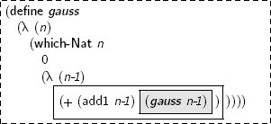

Nice try, and it would deserve a solid box if recursion were an option, but recursion is *not* an option.

<sup>60</sup>

Why not?

Because recursion is not an option.

<sup>61</sup>

Why not?

Because recursion is not an option.

<sup>62</sup>

Okay. Please explain why recursion is not an option.

Recursion is not an option because every expression must have a value. Some recursive definitions make it possible to write expressions that do not have values.

<sup>63</sup>

What is an example of a recursive definition and an expression without a value?

*forever* is such a definition.

(**claim** *forever*

(→ Nat

Atom))

(**define** *forever*

(λ (*and-ever*)

(*forever and-ever*)))

What is the value of (*forever* 71)?

<sup>64</sup>

Good question.

Why does it have a dashed box?

Recursion is not an option, so recursive definitions (like *forever*) stay dashed forever.

<sup>65</sup>

But what about definitions like *gauss* that need recursion?

There is a safe alternative to recursive definitions. This alternative allows *gauss*, along with many similar definitions, to be written without including the name *gauss*.

<sup>66</sup>

Here is the start of a safe alternative definition of *gauss*.

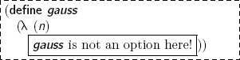

As far as it goes, it is correct. The point is that *gauss* cannot occur in its own definition.

<sup>67</sup>

Now it is clear what is meant by “Recursion is not an option.”

Does this mean that it is impossible to write *gauss* in Pie?

It *is* possible to write *gauss* in Pie, but **which-Nat** and **define** are not up to the task. A different eliminator is needed, but the time is not yet ripe.

<sup>68</sup>

Patience is a virtue.

It is also possible to define shorter names for expressions such as (Pair Nat Nat).

<sup>69</sup>

What is the **claim** in this case?

Another good question!

Expressions such as Atom, Nat, and (Pair Atom Nat), are types, and each of these types is a *U*.†

_______________

†*U*, pronounced “you,” is short for *universe*, because it describes *all* the types (except for itself).

<sup>70</sup>

Are types values?

Some types are values.

An expression that is a type is a value when it has a type constructor at its top. So far, we have seen the type constructors Nat, Atom, Pair, →, and *U*.

<sup>71</sup>

Are all types values?

**Type Values**

**An expression that is described by a type is a value when it has a constructor at its top. Similarly, an expression that is a type is a value when it has a type constructor at its top.**

[output not shown]

**Every *U* Is a Type**

**Every expression described by** *U* **is a type, but not every type is described by** *U***.**

| Every expression described by *U* is a type, but not every expression that is a type is described by *U*. | <sup>79</sup> | Is (cons Atom Nat) a (Pair *U U*)? |
| --- | --- | --- |
| Yes, it is. Define *Pear* to mean the type of pairs of Nats. | <sup>80</sup> | That must be (**claim *Pear*** *U*) (**define *Pear*** (Pair Nat Nat)) From now on, the meaning of *Pear* is (Pair Nat Nat). The name has only four characters, but the type has fourteen. |
| Is *Pear* the same type as (Pair Nat Nat), everywhere that it occurs? | <sup>81</sup> | Yes, by the Commandment of **define**. |
| Is (cons 3 5) a *Pear*? | <sup>82</sup> | Yes, because (cons 3 5) is a (Pair Nat Nat), and *Pear* is *defined* to be precisely that type. |
| That’s a good point. | <sup>83</sup> | Is *Pear* a value? |
| No. Names defined with **define** are neither type constructors nor constructors. Thus, they are not values. Is there an eliminator for *Pear*? | <sup>84</sup> | Does that mean an eliminator that takes apart values of type *Pear*? |
| Yes. An eliminator for *Pear* must allow the information in values with type *Pear* to be used. | <sup>85</sup> | What does it mean to allow the information to be used? |
| An eliminator for *Pear* that allows the information in any *Pear* to be used is one that applies a function to the two Nat arguments in the *Pear*. | <sup>86</sup> | Okay. |
| Which functions can be applied to two Nats as arguments? | <sup>87</sup> | Here’s one: **+**. |
| What about an expression that exchanges the Nats? | <sup>88</sup> | How about (λ (*a d*) (cons *d a*))? |
| Very good. What about an expression that extracts the first Nat from a *Pear*? | <sup>89</sup> | That must be (λ (*a d*) *a*). |
| Very close. Actually, it would be (λ (*a d*) *a*). | <sup>90</sup> | Okay. But the expression is correct except for dimness, right? |
| Indeed. To get a value of type *X*† from a *Pear*, one must have an expression of type (→ Nat Nat *X*). What type does **+** have? _______________ †*X* can be any type at all. | <sup>91</sup> | It takes two Nats and produces a Nat, so it must be (→ Nat Nat Nat). |
| That’s right. What would be the type of (λ (*a d*) (cons *d a*)), when both *a* and *d* are Nats? | <sup>92</sup> | Clearly it must be (→ Nat Nat *Pear*), which is the same as (→ Nat Nat (Pair Nat Nat)). How can a λ-expression be used with a *Pear*? |

**Definitions Are Unnecessary**

**Everything can be done without definitions, but they do improve understanding.**

[output not shown]

Go eat two tacos de nopales  
but look out for the spines.

*This page is intentionally left blank.*†

_______________

†Recursion can be subtle. Apologies to Guy L. Steele Jr., whose thesis inspired this joke.

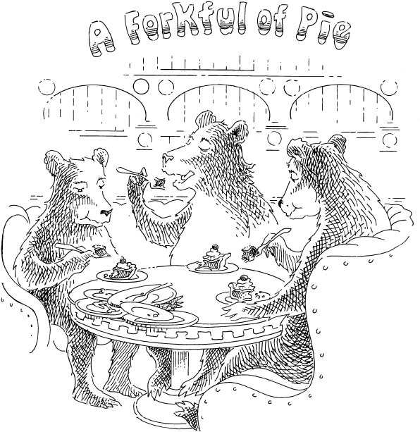

| It’s time to play with Pie. | <sup>1</sup> | Isn’t it impolite to play with your food? |
| --- | --- | --- |
| While pie is indeed a delicious food, Pie is a language, and a little playing around with it won’t hurt. | <sup>2</sup> | Let’s get started. |
| Using Pie is very much like a conversation: it accepts claims, definitions, and expressions and it replies with feedback. | <sup>3</sup> | What sort of feedback? |
| For claims and definitions, the feedback is whether they are meaningful. For expressions, the feedback is also the expression’s type and normal form. | <sup>4</sup> | What if they are not meaningful? |
| Pie explains what is wrong with them, and sometimes adds a helpful hint. | <sup>5</sup> | What might be wrong with an expression? |
| Eat your vegetables before the Pie. Try typing 'spinach and see what happens. | <sup>6</sup> | Pie responds with (the Atom 'spinach). What does the mean here? |
| It means that **'**spinach is an Atom. In Pie, an expression must either be a type or be described by a type. Pie can find the types of many expressions on its own, including atoms. | <sup>7</sup> | What about (**car '**spinach)? |
| That expression is not described by a type because **'**spinach is not a pair. | <sup>8</sup> | Can Pie always determine the type that describes an expression? |
| No, sometimes Pie needs help. In that case, use a the-expression† to tell Pie which type is intended. _______________ †the-expressions are also referred to as *type annotations*. | <sup>9</sup> | For example? |
| Pie cannot determine the type of a cons-expression that stands alone. | <sup>10</sup> | Why not? Isn’t it obvious that (cons **'**spinach **'**cauliflower) is a (Pair Atom Atom)? |
| It is obvious to us, but later, cons becomes more magnificent, and that increased power means that the type cannot be determined automatically. | <sup>11</sup> | How, then, can Pie determine that (cons **'**spinach **'**cauliflower) is a pair? |
| Try this: (the (Pair Atom Atom) (cons 'spinach 'cauliflower)). | <sup>12</sup> | So a the-expression associates an expression with its type, both in Pie’s feedback and in the expressions we write. |

**The Law of** the

**If** *X* **is a type and** *e* **is an** *X***, then**

**(the** *X e***)**

**is an** *X***.**

| There are two kinds of expressions in Pie: those for which Pie can determine a type on its own, and those for which Pie needs our help. | <sup>13</sup> | Are there other ways to help Pie with types? |
| --- | --- | --- |
| Yes. In chapter 1, **claim** is required before its associated **define**, which tells Pie what type to use for the definition’s meaning. | <sup>14</sup> | Why not just use **claim** and **define** every time Pie can’t determine the type of an expression? |
| That would work, but keeping all the names straight might be exhausting. | <sup>15</sup> | Are there any other ways to help Pie find a type? |
| There is one more way. If an expression is used somewhere where only one type makes sense, then that type is used. | <sup>16</sup> | What is an example of this? |
| While checking that (the (Pair Atom (Pair Atom Atom)) (cons 'spinach (cons 'kale 'cauliflower))) is described by a type, Pie uses (Pair Atom Atom) as a type for (cons 'kale 'cauliflower). | <sup>17</sup> | Here, the inner cons doesn’t need a the because its type is coming from the outer cons’s type. Are expressions with the at the top values? |
| No. The value of (the *X e*) is the value of *e*. | <sup>18</sup> | So what is the value of (**car** (the (Pair Atom Nat) (cons **'**brussels-sprout 4)))? |

**The Commandment of** the

**If** *X* **is a type and** *e* **is an** *X***, then**

**(the** *X e***)**

**is the same** *X* **as** *e***.**

[output not shown]

Eat your vegetables  
and enjoy your Pie.

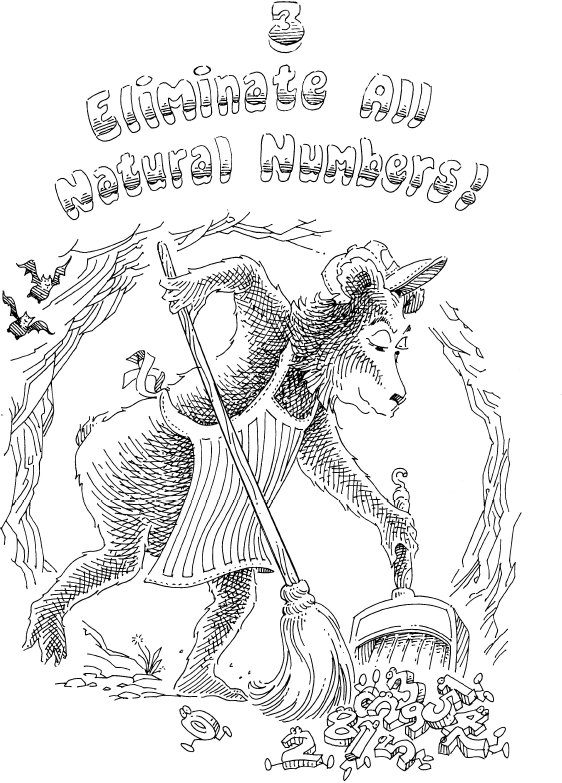

Here is the dashed definition of *gauss* from frame 2:59.

(**define *gauss***

(λ (*n*)

(**which-Nat** *n*

0

(λ (*n-1*)

(**+** (add1 *n-1*) (**gauss** n-1))))))

Now, it is time to define *gauss* properly, without explicit recursion.

<sup>1</sup>

Does that mean that we are about to define *gauss* like this?

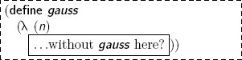

Why are recursive definitions not an option?

<sup>2</sup>

Because **they are not an option**.

Exactly.

But some recursive definitions always yield a value.

<sup>3</sup>

Like *gauss*, right?

That’s right.

What is the normal form of (*gauss* 0)?

<sup>4</sup>

It is zero.

What is the value of (*gauss* 1)?

<sup>5</sup>

_______________

Is that the value?

<sup>6</sup>

Is there more to do?

**Sameness**

**If a “same as” chart could show that two expressions are the same, then this fact can be used anywhere without further justification. “Same As” charts are only to help build understanding.**

[output not shown]

**Total Function**

**A function that always assigns a value to *every* possible argument is called a *total function*.**

[output not shown]

**The Law of iter-Nat**

**If** *target* **is a** Nat**,** *base* **is an** *X***, and** *step* **is an**

**(**→ *X*

*X***)**,

**then**

**(iter-Nat** *target*

*base*

*step***)**

**is an** *X***.**

**The First Commandment of iter-Nat**

**If** (**iter-Nat** zero

*base*

*step*)

**is an** *X***, then it is the same** *X* **as** *base***.**

**The Second Commandment of iter-Nat**

**If** (**iter-Nat** (add1 *n*)

*base*

*step*)

**is an** *X***, then it is the same** *X* **as**

**(***step*

**(iter-Nat** *n*

*base*

*step***))**.

That’s right.

What is the normal form of

(**iter-Nat** 5

3

(λ (*smaller*)

(add1 *smaller*)))?

<sup>20</sup>

It is 8 because add1 applied five times successively to 3 is 8:

(add1

(add1

(add1

(add1

(add1 3))))).

Is the **iter-Nat**-expression’s type the same as *base*’s type?

<sup>21</sup>

It must be, because the value of the **iter-Nat**-expression is the value of *base* when *target* is zero.

Let’s use *X* as a name for *base*’s type.

What is *step*’s type?

<sup>22</sup>

*step* is applied to *base*, and it is also applied to an almost-answer built by *step*. So *step* must be an

(→ *X*

*X*).

Just as with **which-Nat** in frame 2:45, the names *target*, *base*, and *step* are convenient ways to refer to **iter-Nat**’s arguments.

What are the target, base, and step in this **iter-Nat**-expression?

(**iter-Nat** 5

3

(λ (*k*)

(add1 *k*)))

<sup>23</sup>

The target is

5,

The base is

3,

and the step is

(λ (*k*)

(add1 *k*)).

Thus far, we have referred to **+** as if it were completely understood, and assumed that it has a normal form, but there is no definition for **+**.

What should **+**’s type be?

<sup>24</sup>

**+** takes two Nats and returns a Nat.

(**claim +**

(→ Nat Nat

Nat))

That’s right.

If recursion were an option, then this would be a proper definition.

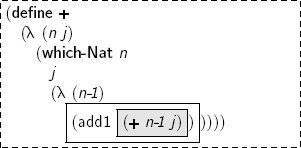

How can **+** be defined with **iter-Nat**?

<sup>25</sup>

Is there a good way to find the step?

The step is based on the wrapper box in the recursive version of **+**. It describes how to change an almost-answer, **+**<sub>*n-1*</sub>, into an answer.

Replace the gray box (which contains the recursion) with the argument to the step as the almost-answer. Remember the white box.

<sup>26</sup>

Here goes.

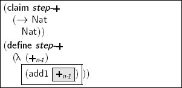

We can’t define a new name unless all the names in both the type and the definition are already defined.†

_______________

†If definitions could refer to each other, then we could not guarantee that every defined function would be a total function.

<sup>27</sup>

And **+** refers to *step-+*, which is now defined. This definition deserves a solid box!

(**define +**

(λ (*n j*)

(**iter-Nat** *n*

*j*

*step-*+)))

Yes, **+** is now defined.

What is (**+** (add1 zero) 7)?

<sup>28</sup>

It is 8 because

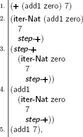

which is 8.

Can **iter-Nat** be used to define *gauss*?

<sup>29</sup>

**iter-Nat** shows a way to repeatedly eliminate the smaller Nat tucked under an add1.

Eliminating the smaller Nat … this sounds like the approach that *gauss* follows.

Close, but the step doesn’t have enough information. *gauss* needs an eliminator that combines the expressiveness of both **which-Nat** and **iter-Nat**. This eliminator is called **rec-Nat**.

<sup>30</sup>

What is **rec-Nat**?

The step for **rec-Nat** is applied to two arguments: the smaller Nat tucked under the add1, and the recursive answer on the smaller Nat. This is the approach used in the definition of *gauss* in frame 2:59.

This is the **rec-Nat** pattern.†

_______________

†The **rec-Nat** pattern is also referred to as *primitive recursion*. Thank you, Rózsa Péter (1905–1977), Wilhelm Ackermann (1896–1962), Gabriel Sudan (1899–1977), and David Hilbert (1862–1943).

<sup>31</sup>

How can *gauss* be defined using **rec-Nat**?

In this frame, there are two definitions of *gauss*: the dashed box from frame 2:59 and a version using **rec-Nat**.

What are the differences?

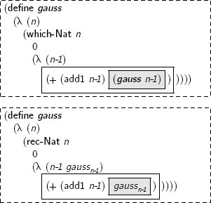

<sup>32</sup>

There are three differences:

1. **which-Nat** is replaced by **rec-Nat**,
2. the inner λ-expression has one more variable, *gauss<sub>n-1</sub>*, and
3. the recursion (**gauss** n-1) is replaced by the almost-answer *gauss<sub>n-1</sub>*.

The names *n-1* and *gauss<sub>n-1</sub>* are chosen to be suggestive of what they mean, but they are just variable names.

The arguments to **rec-Nat** have the same special names as **iter-Nat**: they are always called *target*, *base*, and *step*.

<sup>33</sup>

How can we determine the values of **rec-Nat**-expressions?

As with **iter-Nat**, if the target is zero, then the value of the **rec-Nat**-expression is the value of the base.

<sup>34</sup>

What about when the target has add1 at the top?

**which-Nat** applies its step to the smaller Nat tucked under the add1.

**iter-Nat** applies its step to an **iter-Nat**-expression with the same base and step, but with the smaller Nat tucked under add1 as the new target.

How could these be combined?

<sup>35</sup>

Here is a guess.

The step is applied to the smaller Nat. The step is, however, also applied to a **rec-Nat**-expression with the same base and step, but with that very same smaller Nat as the target.

Good guess. When **rec-Nat** is used with a non-zero Nat as the target, the target shrinks by removing an add1 each time. Once again, the base and step do not change.

What is the value of

(**rec-Nat** (add1 zero)

0

(λ (*n-1 almost*)

(add1

(add1 *almost*))))?

<sup>36</sup>

It is the step applied to zero and the new **rec-Nat** expression. That is,

((λ (*n-1 almost*)

(add1

(add1 *almost*)))

zero

(**rec-Nat** zero

0

(λ (*n-1 almost*)

(add1

(add1 *almost*))))).

The resulting expression in the preceding frame is not a value, but it is the same as the original one.

What is the value?

<sup>37</sup>

It is

(add1

(add1

(**rec-Nat** zero

0

(λ (*n-1 almost*)

(add1

(add1 *almost*)))))),

which is a value because it has add1 at the top.

What is its normal form?

<sup>38</sup>

It is

(add1

(add1 0)).

The target is zero and the base is 0.

A **rec-Nat**-expression is an expression only if the target is a Nat.

<sup>39</sup>

What type should the base and step have?

The base must have some type. Let’s call it *X*, again. *X* can be any type, but the **rec-Nat**-expression has the same type as the base—namely *X*.

<sup>40</sup>

Is that all?

No.

If the base is an *X*, then the step must be an

(→ Nat *X*

*X*).

Why is this the right type for the step?

<sup>41</sup>

The step is applied to two arguments: the first is a Nat because it is tucked under an add1 in a target. The second argument is *almost*. *almost* is an *X* because *almost* is also built by **rec-Nat**.

How does this relate to the step’s type in **which-Nat** and **iter-Nat**?

<sup>42</sup>

Like **which-Nat**, **rec-Nat**’s step accepts the smaller Nat tucked under the target’s add1. Like **iter-Nat**, it also accepts the recursive almost-answer.

Here is a function that checks whether a Nat is zero.

(**claim *step-zerop***

(→ Nat Atom

Atom))

(**define *step-zerop***

(λ (*n-1 zerop<sub>n-1</sub>*)

**'**nil))

(**claim *zerop***

(→ Nat

Atom))

(**define *zerop***

(λ (*n*)

(**rec-Nat** *n*

**'**t

*step-zerop*)))†

_______________

†We use **'**t and **'**nil as two arbitrary values. This may be familiar to Lispers (Thank you, John McCarthy (1927–2011)), but *zerop* is called *zero?* in Scheme (Thanks, Gerald J. Sussman (1947–) and Guy L Steele (1954–)).

<sup>43</sup>

Why use **rec-Nat**, which is recursive, to define something that only needs to determine whether the top constructor is zero or add1? After all, **which-Nat** would have been good enough.

**which-Nat** is easy to explain, but **rec-Nat** can do anything that **which-Nat** (and **iter-Nat**) can do.

Why are the *λ*-variables in *step-zerop* called *n-1* and *zerop<sub>n-1</sub>*?

<sup>44</sup>

The name *n-1* is once again chosen to suggest one less than *n* because it is one less than the target Nat, that is, the Nat expression being eliminated. The name *zerop<sub>n-1</sub>* suggests (**zerop** n-1).

The step is merely a λ-expression, so any other unused variable names would work, but this style of naming variables in steps is used frequently.

Both arguments to *step-zerop* are unused, which is why they are dim. Thus, the definition only seems to be recursive; in fact, it is not.

<sup>45</sup>

What is the point of a λ-expression that does not use its arguments?

The step used with **rec-Nat** always takes two arguments, though it need not always use them.

What is the value of (*zerop* 37)?

<sup>46</sup>

Let’s see.

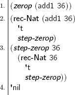

The value is determined immediately. The value for 36, which is (add1 35), is not necessary, so there’s no reason to find it.

We need not evaluate expressions until their values actually become necessary. Otherwise, it would take a lot of work to evaluate the argument to *step-zerop*

(**rec-Nat** 36

**'**t

*step-zerop*),

so the “same as” chart would have at least 105 more lines.

<sup>47</sup>

Sometimes laziness is a virtue.

Is (*zerop* 37) the same as (*zerop* 23)?

<sup>48</sup>

Yes indeed.

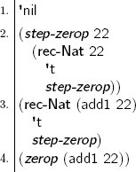

Here is the step for *gauss*.

(**claim *step-gauss***

(→ Nat Nat

Nat))

(**define *step-gauss***

(λ (*n-1 gauss<sub>n-1</sub>*)

(**+** (add1 *n-1*) *gauss<sub>n-1</sub>*)))

<sup>49</sup>

This definition uses the naming convention from frame 44.

Yes, it does.

Another advantage of defining a step is that its type is written explicitly, rather than implied by its use in **rec-Nat**.

<sup>50</sup>

The explicit type does make it easier to read and understand the definition.

λ-variables in a step like *zerop<sub>n-1</sub>* and *gauss<sub>n-1</sub>* are *almost* the answer, in the sense of frame 2:56.

<sup>51</sup>

Okay.

What is the solid-box definition of *gauss*?

Here it is.

(**define *gauss***

(λ (*n*)

(**rec-Nat** *n*

0

*step-gauss*)))

What is the base?

<sup>52</sup>

The base is the second argument to **rec-Nat**. In this case, it is 0, which is a Nat.

What is the step?

<sup>53</sup>

It is *step-gauss*.

Indeed it is.

<sup>54</sup>

What is (*gauss* zero) using this definition?

It is 0 because

(**rec-Nat** zero

0

*step-gauss*)

is the same as the second argument to **rec-Nat**, which is 0.

Here is a start for finding the value of (*gauss* (add1 zero)).

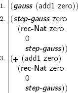

Now finish finding the value.

<sup>55</sup>

Here we go.

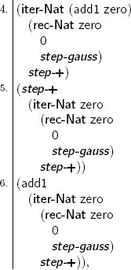

which is a value because it has add1 at the top.

Is that value normal?

<sup>56</sup>

Why is **rec-Nat** always safe to use?

<sup>57</sup>

That’s a good question.

When the target has add1 at its top, then **rec-Nat** is recursive. If recursion is not an option, why is this acceptable?

If the step does not rely on the almost-answer, as in frame 43, then a value has already been reached. If the step does rely on the almost-answer, then the recursion is guaranteed to reach the base, which is always a value or an expression that becomes a value.

<sup>58</sup>

How do we know that?

Because every target Nat is the same as either zero or (add1 *n*), where *n* is a smaller Nat.

<sup>59</sup>

How do we know that *n* is smaller?

The only way that it could be the same or larger is if the target Nat were built from infinitely many add1s. But because every function is total, there is no way to do this. Likewise, no step can fail to be total, because here *all* functions are total, and each step applies a function.

<sup>60</sup>

So why can’t we use this style of reasoning for any recursive definition?

This style of reasoning cannot be expressed with our tools. But once we are convinced that **rec-Nat** with a total step is a way to eliminate any target Nat, we no longer need to reason carefully that each new definition is total.†

_______________

†Loosely speaking: we can’t, but even if we were able to, it would be exhausting.

<sup>61</sup>

Are there more interesting examples of definitions using **rec-Nat**?

It can be used to define **∗**† to mean multiplication.

In other words, if *n* and *j* are Nats, then

(**∗** *n j*)

should be the product of *n* and *j*.

_______________

†**∗** is pronounced “times.”

<sup>62</sup>

**∗** takes two Nats and their product is a Nat. So here is **∗**’s type.

(**claim∗**

(→ Nat Nat

Nat))

At each step, **+** adds one to the answer so far. What does **∗** do at each step?

<sup>63</sup>

**∗** adds *j*, its second argument, to the almost-answer.

Here is *make-step-*∗, which yields a step function for any *j*.

(**claim *make-step-*****∗**

(→ Nat

(→ Nat Nat

Nat)))

(**define *make-step-*∗**

(λ (*j*)

(λ (*n-1* **∗**<sub>*n-1*</sub>)

(**+** *j* **∗**<sub>n-1</sub>))))

<sup>64</sup>

That doesn’t look like the preceding steps.

Now define **∗**

<sup>65</sup>

Okay.

The argument to *make-step-*∗. is *j*, which is added to the product at each step. The base is 0 because multiplying by zero is 0.

(**define ∗**

(λ (*n j*)

(**rec-Nat** *n*

0

(*make-step-*∗ *j*))))

It may look as though *make-step-*∗ is doing something new. It is a λ-expression that produces a new λ-expression. Instead of this two-step process, it is possible to collapse the nested λs into a single λ.

(**claim *step-*∗**

(→ Nat Nat Nat

Nat))

(**define *step-*∗**

(λ (*j n-1* **∗**<sub>*n-1*</sub>)

(**+** *j* **∗**<sub>*n-1*</sub>)))

*make-step-*∗ produces a step for any given *j*. And, despite their seeming difference, *make-step-*∗ and *step*-∗ have the *same definition*.

<sup>66</sup>

That can’t be the same definition. It has a three-argument λ-expression.

In fact, all λ-expressions expect exactly one argument.

(λ (*x y z*)

(**+** *x* (**+** *y z*)))

is merely a shorter way of writing

(λ (*x*)

(λ (*y*)

(λ (*z*)

(**+** *x* (**+** *y z*))))).

<sup>67</sup>

Does that mean that

(→ Nat Nat Nat

Nat)

is also a shorter way of writing something?

It is a shorter way of writing

(→ Nat

(→ Nat

(→ Nat

Nat))).

<sup>68</sup>

If a function takes three arguments, it is possible to apply the function to just one of them.

Is it also possible to apply the function to just two arguments?

If *f* is an

(→ Nat Nat Nat

Nat)

then

(*f x y z*)

is merely a shorter way of writing

((*f x y*) *z*),

which is a shorter way of writing

(((*f x*) *y*) *z*).

<sup>69</sup>

Does this mean that every function takes exactly one argument?

Indeed. Every function takes exactly one argument.

Defining functions that take multiple arguments as nested one-argument functions is called *Currying*.†

_______________

†Thank you, Haskell B. Curry (1900–1982) and Moses Ilyich Schönfinkel (1889–1942).

<sup>70</sup>

Now the definition of **∗** deserves a box.

(**define∗**

(λ (*n j*)

(**rec-Nat** *n*

0

(*step-*∗ *j*))))

Even though *step-*∗ looks like a three-argument λ-expression, it can be given just one argument. **rec-Nat** expects that its *step* is a function that would get exactly two arguments.

Here are the first five lines in the chart for the normal form of (**∗** 2 29).

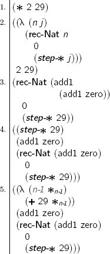

Now, find its normal form.

<sup>71</sup>

Ah, Currying is involved.

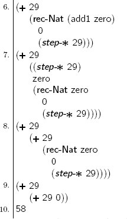

Are any steps left out of this chart?

**The Law of rec-Nat**

**If** *target* **is a** Nat**,** *base* **is an** *X***, and** *step* **is an**

**(**→ Nat *X*

*X***)**

**then**

**(rec-Nat** *target*

*base*

*step***)**

**is an** *X***.**

**The First Commandment of rec-Nat**

**If** (**rec-Nat** zero

*base*

*step*)

**is an** *X***, then it is the same** *X* **as** *base***.**

**The Second Commandment of rec-Nat**

**If** (**rec-Nat** (add1 *n*)

*base*

*step*)

**is an** *X***, then it is the same** *X* **as**

**(***step n*

**(rec-Nat** *n*

*base*

*step***))**.

Yes, making (**+** 29 0) and the resultant (**+** 29 29) normal.†

_______________

†This chart saves paper, energy, and time.

<sup>72</sup>

Thanks.

At first, this chart seemed like it would be tedious.

That’s just right.

What is a good name for this definition?

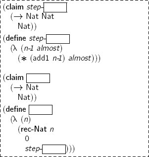

<sup>73</sup>

This function always returns 0.

Very observant.

A shortcoming of types like Nat is that they don’t say anything about *which* Nat was intended. Later, we encounter more powerful types that allow us to talk about *particular* Nats.†

_______________

†Actually, the definition in frame 73 was supposed to be *factorial*. The oversight, however, survived unnoticed in more drafts than the authors would like to admit. We leave the task of correcting it to the reader.

<sup>74</sup>

So these powerful types prevent defining *five* to be 9 as in frame 2:36?

Absolutely not.

Types do not prevent foolishness like defining *five* to be 9. We can, however, write *some* of our thoughts as types.

<sup>75</sup>

Interesting.

**Go eat (+ 2 2) bananas, and rest up.**

[figure not shown]

[output not shown]

**The Intermediate Law of Application**

**If** *f* **is a**

**(Π ((***Y U***))**

*X***)**

**and** *Z* **is a** *U***, then**

**(***f Z***)**

**is an** *X*

**where every** *Y* **has been consistently replaced by** *Z***.**

[output not shown]

**Now go to your favorite confectionary shop and share a delicious cherry Π.**

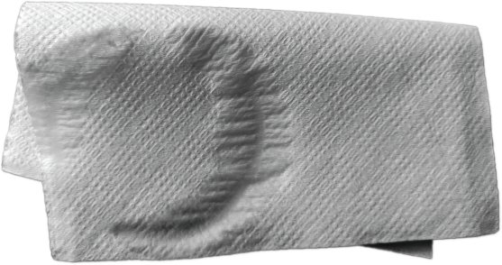

*Ceci n’est pas une serviette.*†

_______________

†Thank you, René François Ghislain Magritte (1898–1967).

[figure not shown]

How was that Π?

<sup>1</sup>

Delicious. A napkin would have made eating less messy, though.

Before we begin, have you

- cooked ratatouille,
- eaten two pieces of cherry pie,
- tried to clean up with a picture of a napkin,
- understood **rec-Nat**, and
- slept until well-rested?

<sup>2</sup>

That’s quite the list of expectations.

Yes, but they’re great expectations.

(**claim *expectations***

(List Atom))

(**define *expectations***

(:: **'**cooked

(:: **'**eaten

(:: **'**tried-cleaning

(:: **'**understood

(:: **'**slept nil))))))

<sup>3</sup>

This is confusing in these ways:

- :: has not yet been described,
- the type constructor List has not been described, and
- the atom **'**nil has been used as part of *step-zerop*.

Is **'**nil the same as nil in frame 3?

<sup>4</sup>

No, it isn’t, because the nil in frame 3 is not an Atom—it does not begin with a tick mark.

Is nil an expression?

List is a type constructor. If *E* is a type, then (List *E*)† is a type.

_______________

†Pronounced “list of entries of type *E*,” or simply “list of *E*.”

<sup>5</sup>

What does it mean to be a (List *E*), then?

**The Law of** List

**If** *E* **is a type,**

**then (**List *E***) is a type.**

Is nil a (List Atom)?

<sup>6</sup>

nil looks like it plays the role of the empty list in frame 3.

Yes, nil is a (List Atom).

Is nil a (List Nat)?

<sup>7</sup>

Not likely, because nil is a (List Atom).

Actually, nil is a (List Nat) as well.

Is nil a (List (List Atom))?

<sup>8</sup>

Yes, because (List Atom) is a type, so (List (List Atom)) is also a type. What about (List (Pair Nat Atom))?

Is nil one of those, too?

Yes, it is.

<sup>9</sup>

Does that mean that nil is a

(List **'**potato)

as well?

No, it is not, because **'**potato is not a type.

<sup>10</sup>

Is it for the same reason that

(Pair **'**olive **'**oil)

in frame 1:52 is not a type?

Yes.

(List **'**potato) is not a type, because **'**potato is an Atom, not a type.

<sup>11</sup>

Okay. This means that if *E* is a type, then (List *E*) is a type, right?

And if (List *E*) is a type, then nil is a (List *E*).

<sup>12</sup>

All right.

Is nil a constructor?

Yes, nil is a constructor.

Guess the other constructor of (List *E*).

<sup>13</sup>

Based on *expectations*, :: is the other constructor.

How does ::† differ from cons?

The constructor :: builds a List …

_______________

†For historical reasons, :: is also pronounced “cons” or “list-cons.”

<sup>14</sup>

… but the constructor cons builds a Pair.

It is possible to have a list of pairs, or a pair of lists.

When is (:: *e es*†) a (List *E*)?

_______________

†The plural of *e* is *es* and is pronounced *ease*. *es* is used because the rest of a list could have any number of entries.

<sup>15</sup>

Well, *es* must be a (List *E*). *es* could be nil, and nil is a (List *E*).

Can *e* be anything at all?

<sup>16</sup>

Of course!

Of course not! Try again.

<sup>17</sup>

Here’s a guess: *e* must be an *E* because *E* has not yet been used for anything else.

Right answer; wrong reason.

*e* must be an *E* because in order to use an eliminator for (List *E*), we must know that everything in the list is an *E*.

Define *rugbrød*† to be the ingredients of Danish rye bread.

_______________

<sup>18</sup>

What are the ingredients?

The ingredients in *rugbrød* are:

- whole-grain rye flour,
- rye kernels, soaked until soft,
- pure water,
- active sourdough, and
- salt.

<sup>19</sup>

What type should *rugbrød* have?

(List Atom), because each ingredient is an Atom.

<sup>20</sup>

Okay, here goes.

(**claim *rugbrød***

(List Atom))

(**define *rugbrød***

(:: **'**rye-flour

(:: **'**rye-kernels

(:: **'**water

(:: **'**sourdough

(:: **'**salt nil))))))

Very good.

<sup>21</sup>

Yes, *rugbrød* is quite tasty! It does need something on top, though.

Let’s get back to that.

How does *rugbrød* differ from 5?

<sup>22</sup>

They appear to have nothing in common. 5 is made up of add1 and zero. Also, 5 is not tasty.

How many ingredients does *rugbrød* contain?

<sup>23</sup>

Five.

In addition to only requiring five ingredients, *rugbrød* doesn’t even need kneading.

<sup>24</sup>

Does :: have something to do with add1, then?

:: makes a list bigger, while add1 makes a Nat bigger.

Does nil have something to do with zero as well?

<sup>25</sup>

nil is the smallest list, while zero is the smallest Nat.

Does the eliminator for lists look like one for Nats?

**The Law of** nil

nil **is a (**List *E***), no matter what type** *E* **is.**

**The Law of** ::

**If** *e* **is an** *E* **and** *es* **is a (**List *E***),**

**then (**:: *e es***) is a (**List *E***).**

Yes, it does.

What type does

(**rec-Nat** *target*

*base*

*step*)

have?

<sup>26</sup>

The **rec-Nat**-expression is an *X* when

- *target* is a Nat,
- *base* is an *X*, and
- *step* is an (→ Nat *X X*).

The eliminator for (List *E*) is written

(**rec-List** *target*

*base*

*step*)

and it is an *X* when

- *target* is a (List *E*),
- *base* is an *X*, and
- *step* is an (→ *E* (List *E*) *X X*).

How does this differ from **rec-Nat**?

<sup>27</sup>

**rec-List**’s *step* takes one more argument than **rec-Nat**’s *step*—it takes *e*, an entry from the list.

Nicely done!

In both cases, the step accepts every argument from the corresponding constructor as well as the recursive elimination of the smaller value.

<sup>28</sup>

Eliminators expose the information in values.

The base exposes a lot of information about the result of a **rec-List**. What are two uses of **rec-List** that have 0 as their base?

<sup>29</sup>

One use is to find the length of a list. Another is to find the sum of all the Nats in a (List Nat).

Those are two good examples.

With this definition

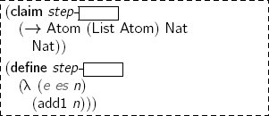

what is the value of

(**rec-List** nil

It must be 0, because 0 is the base and the value of the base must be the value for nil.

That’s right.

A *kartoffelmad* is *rugbrød* with *toppings* and *condiments*.

(**claim *toppings***

(List Atom))

(**define *toppings***

(:: **'**potato

(:: **'**butter† nil)))

(**claim *condiments***

(List Atom))

(**define *condiments***

(:: **'**chives

(:: **'**mayonnaise† nil)))

_______________

†Or your favorite non-dairy alternative.

<sup>31</sup>

That sounds *lækkert*!

**The Law of rec-List**

**If** *target* **is a (**List *E***),** *base* **is an** *X***, and** *step* **is an**

**(**→ *E* **(**List *E***)** *X*

*X***)**,

**then**

**(rec-List** *target*

*base*

*step***)**

**is an** *X***.**

**The First Commandment of rec-List**

**If** (**rec-List** nil

*base*

*step*)

**is an** *X***, then it is the same** *X* **as** *base***.**

**The Second Commandment of rec-List**

**If** (**rec-List** (:: *e es*)

*base*

*step*)

**is an** *X***, then it is the same** *X* **as**

**(***step e es*

**(rec-List** *es*

*base*

*step***))**.

It is!

What is the value of

(**rec-List *condiments***

Let’s see.

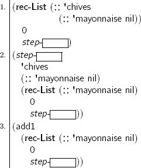

What is the normal form? Feel free to leave out the intermediate expressions.

<sup>33</sup>

The normal form is

(add1

(add1 zero)),

better known as 2.

The **rec-List** expression replaces each :: in *condiments* with an add1, and it replaces nil with 0.

What is a good name to fill in the box?

<sup>34</sup>

The name *length* seems about right.

(**claim *step-length***

(→ Atom (List Atom) Nat

Nat))

(**define *step-length***

(λ (*e es length<sub>es</sub>*)

(add1 *length<sub>es</sub>*)))

Then this must be *length*.

(**claim *length***

(→ (List Atom)

Nat))

(**define *length***

(λ (*es*)

(**rec-List** *es*

0

*step-length*)))

<sup>35</sup>

But what about the length of

(:: 17

(:: 24

(:: 13 nil)))?

That’s easy, just replace Atom with Nat.

(**claim *step-length***

(→ Nat (List Nat) Nat

Nat))

(**define *step-length***

(λ (*e es length<sub>es</sub>*)

(add1 *length<sub>es</sub>*)))

<sup>36</sup>

And here’s *length* for a list of Nats.

(**claim *length***

(→ (List Nat)

Nat))

(**define *length***

(λ (*es*)

(**rec-List** *es*

0

*step-length*)))

Lists can contain entries of any type, not just Atom and Nat.

What can be used to make a version of *step-length* that works for all types?

<sup>37</sup>

It’s as easy as Π.

(**claim *length***

(Π ((*E U*))

(→ (List *E*)

Nat)))

That **claim** requires a step.

(**claim *step-length***

(Π ((*E U*))

(→ *E* (List *E*) Nat

Nat)))

<sup>38</sup>

At each step, the length grows by add1.

(**define *step-length***

(λ (*E*)

(λ (*e es length<sub>es</sub>*)

(add1 *length<sub>es</sub>*))))

This uses the same technique as *step-*∗ in frame 3:66 to apply *step-length* to *E*.

Now define *length*.

<sup>39</sup>

Passing *E* to *step-length* causes it to take three arguments.

(**define *length***

(λ (*E*)

(λ (*es*)

(**rec-List** *es*

0

(**step-length** E)))))

Why is *e* in *step-length* dim?

<sup>40</sup>

Because the specific entries in a list aren’t used when finding the length.

What is the value of (*length* Atom)?

<sup>41</sup>

It is

(λ (*es*)

(**rec-List** *es*

0

(*step-length* Atom))),

which is found by replacing each *E* with Atom in the inner λ-expression’s body.

Define a specialized version of *length* that finds the number of entries in a (List Atom).

<sup>42</sup>

This uses the same technique as the definition of *twin-Atom* in frame 4:54.

(**claim *length-Atom***

(→ (List Atom)

Nat))

(**define *length-Atom***

(*length* Atom))

That is a useful technique.

Now it is time to assemble a delicious *kartoffelmad* from a slice of bread, *toppings*, and *condiments*.

Define a function that appends two lists.

<sup>43</sup>

What should be the definition’s type?

Is it possible to append a (List Nat) and a (List (Pair Nat Nat))?

<sup>44</sup>

No.

All the entries in a list must have the same type.

**List Entry Types**

**All the entries in a list must have the same type.**

As long as two lists contain the same entry type, they can be appended, no matter which entry type they contain.

What does this say about the type in *append*’s definition?

<sup>45</sup>

The type must be a Π-expression.

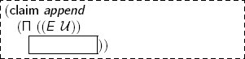

Exactly.

What are the rest of the arguments?

<sup>46</sup>

There must be two (List *E*) arguments. Also, the result is a (List *E*). From that, *append* must be a λ-expression.

Here is the claim. Now start the definition.

(**claim *append***

(Π ((*E U*))

(→ (List *E*) (List *E*)

(List *E*))))

<sup>47</sup>

It is a λ-expression, but the body remains a mystery.

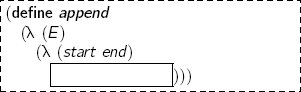

What goes in the box?

<sup>48</sup>

Some kind of **rec-List**.

What is the value of

(*append* Atom

nil

(:: **'**salt

(:: **'**pepper nil)))?

<sup>49</sup>

Clearly it must be

(:: **'**salt

(:: **'**pepper nil)).

And what is the normal form of

(*append* Atom

(:: **'**cucumber

(:: **'**tomato nil))

(:: **'**rye-bread nil))?

<sup>50</sup>

It must be

(:: **'**cucumber

(:: **'**tomato

(:: **'**rye-bread nil))).

The value of (**append** E nil *end*) should be the value of *end*. Thus, *append*’s last argument *end* is the base.

<sup>51</sup>

What about the step?

The step’s type is determined by the Law of **rec-List**. It should work for any entry type.

<sup>52</sup>

How about this one?

(**claim *step-append***

(Π ((*E U*))

(→ *E* (List *E*) (List *E*)

(List *E*))))

Using the previous frame as an example, fill in the rest of *step-append*.†

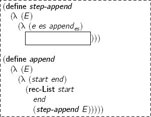

_______________

†The expression (**step-append** E) should be a step for *append* when the list contains entries of type *E*. Be mindful of the Currying.

<sup>53</sup>

If *append<sub>es</sub>* is

nil,

then the *step-append* should produce

(:: **'**rye-bread nil).

If *append<sub>es</sub>* is

(:: **'**rye-bread nil),

then the *step-append* should produce

(:: **'**tomato

(:: **'**rye-bread nil)).

Finally, if *append<sub>es</sub>* is

(:: **'**tomato

(:: **'**rye-bread nil)),

then the *step-append* should produce

(:: **'**cucumber

(:: **'**tomato

(:: **'**rye-bread nil))).

That is good reasoning.

What is the proper definition?

<sup>54</sup>

Now *append* deserves a solid box.

(**define *step-append***

(λ (*E*)

(λ (*e es append<sub>es</sub>*)

(:: *e append<sub>es</sub>*))))

(**define *append***

(λ (*E*)

(λ (*start end*)

(**rec-List** *start*

*end*

(**step-append** E)))))

This definition of *append* is very much like **+**.

<sup>55</sup>

Is there an **iter-List**, like **iter-Nat**, and could it be used to define *append*?

Nothing would stop us from defining **iter-List**, but there is no need, because **rec-List** can do everything that **iter-List** could do, just as **rec-Nat** can do everything that **iter-Nat** and **which-Nat** can do.

<sup>56</sup>

Okay, let’s use the more expressive eliminators here.

Not every list is in the order that one might want. For instance,

(:: **'**plate

(:: **'**rye-bread nil))

puts a plate in the way of the fork and knife, and makes a mess of the table.

<sup>57</sup>

That list is backwards.

The first step to getting this list in the right order is to define a useful helper, called *snoc*.

<sup>58</sup>

What is *snoc*?

Just as :: “cons”es entries onto the front of a list, *snoc*† places an entry onto the back of a list.

For example, the value of

(*snoc* Atom *toppings* 'rye-bread)

is

(:: **'**potato

(:: **'**butter

(:: **'**rye-bread nil))).

What is *snoc*’s type?

_______________

†Thanks, David C. Dickson (1947–)

<sup>59</sup>

Here it is.

(**claim *snoc***

(Π ((*E U*))

(→ (List *E*) *E*

(List *E*))))

What must the step do?

The step must “cons” the current entry of the list onto the result.

<sup>60</sup>

Oh, so it’s just like *step-append*.

In fact, *step-append* is precisely what’s needed.

<sup>61</sup>

That must mean that there’s no need to define a separate step for *snoc*.

Indeed.

Now define *snoc*.

<sup>62</sup>

Here is *snoc*.

(**define *snoc***

(λ (*E*)

(λ (*start e*)

(**rec-List** *start*

(:: *e* nil)

(**step-append** E)))))

Now that *snoc* is defined, it’s time to get

(:: **'**plate

(:: **'**rye-bread nil))

into an order that is more suitable for dining.

<sup>63</sup>

How about calling this new function *reverse*?

That’s a good name.

What should the type of *reverse* be?

<sup>64</sup>

*reverse* accepts a single list as an argument.

(**claim *reverse***

(Π ((*E U*))

(→ (List *E*)

(List *E*))))

What should be done at each step?

<sup>65</sup>

At each step, *e* should be *snoc*’d onto the back of the reversed *es*.

(**claim *step-reverse***

(Π ((*E U*))

(→ *E* (List *E*) (List *E*)

(List *E*))))

Now define *step-reverse* and *reverse*.

<sup>66</sup>

Here they are.

(**define *step-reverse***

(λ (*E*)

(λ (*e es reverse<sub>es</sub>*)

(**snoc** E reverse<sub>es</sub> e))))

(**define *reverse***

(λ (*E*)

(λ (*es*)

(**rec-List** *es*

nil†

(**step-reverse** E)))))

_______________

†When using Pie, it is necessary to replace this nil with (the (List E) nil).

Now it is time for something *lækkert*.

(**claim *kartoffelmad***

(List Atom))

(**define *kartoffelmad***

(*append* Atom

(*append* Atom

*condiments toppings*)

(*reverse* Atom

(:: **'**plate

(:: **'**rye-bread nil)))))

What is *kartoffelmad*’s normal form?

<sup>67</sup>

It is

(:: **'**chives

(:: **'**mayonnaise

(:: **'**potato

(:: **'**butter

(:: **'**rye-bread

(:: **'**plate nil)))))).

It’s a good thing we asked for the normal form instead of the value. Otherwise, you’d have to assemble all but the **'**chives while eating it!

<sup>68</sup>

Reversing lists is hungry work.

**Have yourself a nice *kartoffelmad*,**

**and get ready for more delicious Π.**

**RUGBRØD**

[output not shown]

**KARTOFFELMAD**

Take a thin slice of rugbrød, approximately 0.75cm. Spread it with butter. Artfully arrange slices of cooled boiled new potato on the buttered bread, and top with mayonnaise and chives.

**LÆKKERT!**

[figure not shown]

| … | <sup>1</sup> | After all that sandwich, some Π would go great. |
| --- | --- | --- |
| We’re glad you asked … | <sup>2</sup> | I’m pretty good at anticipating what you want me to ask. |
| Naturally. Let’s get started. Let’s define a function *first* that finds the first entry in *any* List. | <sup>3</sup> | Wouldn’t that be easy to do? |
| Actually, it would be impossible! | <sup>4</sup> | Why would it be impossible? |
| It is impossible because nil has no first entry … | <sup>5</sup> | … and therefore *first* would not be total. |
| What about a function, *last* that, instead of finding the first entry, finds the last entry in a List? | <sup>6</sup> | The function *last* would also not be total, because nil has no last entry. |
| To write a total function *first*, we must use a more specific type constructor than List. This more specific type constructor is called Vec, which is short for “vector,” but it is really just a list … | <sup>7</sup> | Can types contain expressions that aren’t types? |
| Just as types can be the outcome of evaluating an expression (as in frame 1:55), some types contain other expressions that are not themselves types. | <sup>8</sup> | Then (Vec Atom 3) is a type because Atom is a type and 3 is clearly a Nat. |
| Is (Vec (**cdr** (cons **'**pie (List (**cdr** (cons Atom Nat))))) (**+** 2 1)) a type? | <sup>9</sup> | It must be, because (**cdr** (cons **'**pie (List (**cdr** (cons Atom Nat))))) and (List Nat) are the same type, and because (**+** 2 1) is the same Nat as 3. That means that the expression is the sam… |
| The only constructor of (Vec *E* zero) is vecnil. | <sup>10</sup> | Is this because the length of vecnil is zero? |
| Precisely. vec:: is the only constructor of (Vec *E* (add1 *k*)). | <sup>11</sup> | What is *k* here? |
| Here, *k* can be any Nat. (vec:: *e es*) is a (Vec *E* (add1 *k*)) when *e* is an *E* and *es* is a (Vec *E k*). | <sup>12</sup> | If an expression is a (Vec *E* (add1 *k*)), then its value has at least one entry, so it is possible to define *first* and *last*, right? |
| Right. Is (vec:: **'**oyster vecnil) a (Vec Atom 1)? | <sup>13</sup> | Yes, because **'**oyster is an Atom and vecnil is a (Vec Atom zero). |

**The Law of** Vec

**If** *E* **is a type and** *k* **is a** Nat**,**

**then (**Vec *E k***) is a type.**

**The Law of** vecnil

vecnil **is a (**Vec *E* zero**).**

**The Law of** vec::

**If** *e* **is an** *E* **and** *es* **is a (**Vec *E k***),**

**then (**vec:: *e es***) is a (**Vec *E* **(**add1 *k***)).**

| Is (vec:: **'**crimini (vec:: **'**shiitake vecnil)) a (Vec Atom 3)? | <sup>14</sup> | No, because it is not a list of precisely three atoms. |
| --- | --- | --- |
| How does this relate to frame 11? | <sup>15</sup> | It is not a (Vec Atom 3) because (vec:: **'**shiitake vecnil) is not a (Vec Atom 2). |
| Why is (vec:: **'**shiitake vecnil) not a (Vec Atom 2)? | <sup>16</sup> | If it were, then vecnil would have to be a (Vec Atom 1), based on the description in frame 11. |
| Why can’t that be the case? | <sup>17</sup> | Because vecnil is a (Vec Atom zero), and 1 is not the same Nat as zero. |
| Why is 1 not the same Nat as zero? | <sup>18</sup> | Frame 1:100 explains that two Nats are the same when their values are the same, and that their values are the same when either both are zero or both have add1 at the top. |
| It is now possible to define *first-of-one*, which gets the first entry of a (Vec *E* 1). | <sup>19</sup> | But is it possible? So far, there are no eliminators for Vec. |
| Good point. Two of the eliminators for Vec are **head** and **tail**. | <sup>20</sup> | What do **head** and **tail** mean? |
| (**head** *es*) is an *E* when *es* is a (Vec *E* (add1 *k*)). What form can the value of *es* take? | <sup>21</sup> | It cannot be vecnil because vecnil has zero entries. So *es* has vec:: at the top. |
| The expression (**head** (vec:: *a d*)) is the same *E* as *a*. | <sup>22</sup> | What about **tail**? |
| (**tail** *es*) is a (Vec *E k*) when *es* is a (Vec *E* (add1 *k*)). | <sup>23</sup> | *es* has vec:: at the top. Is (**tail** (vec:: *a d*)) the same *E* as *d*? |
| No, but (**tail** (vec:: *a d*)) is the same (Vec *E k*) as *d.* Now define *first-of-one*. | <sup>24</sup> | *first-of-one* uses **head** to find the only entry. (**claim *first-of-one*** (Π ((*E U*)) (→ (Vec *E* 1) *E*))) (**define *first-of-one*** (λ (*E*) (λ (*es*) (**head** *es*)))) |
| What is the value of (*first-of-one* Atom (vec:: **'**shiitake vecnil))? | <sup>25</sup> | It is **'**shiitake. |
| What is the value of (*first-of-one* Atom vecnil)? | <sup>26</sup> | That question is meaningless because (*first-of-one* Atom vecnil) is not described by a type, and this is because vecnil is not a (Vec Atom 1). |
| That’s right, the question is meaningless. Now define *first-of-two*. | <sup>27</sup> | It is very much like *first-of-one*. (**claim *first-of-two*** (Π ((*E U*)) (→ (Vec *E* 2) *E*))) (**define *first-of-two*** (λ (*E*) (λ (*es*) (**head** *es*)))) |
| What is the value of (*first-of-two* Atom (vec:: **'**matsutake (vec:: **'**morel (vec:: **'**truffle vecnil))))? | <sup>28</sup> | That is quite a valuable list of mushrooms. The question, however, doesn’t make sense because that valuable list of mushrooms has three, instead of precisely two, mushrooms. |
| Good point. It is now time for *first-of-three*. | <sup>29</sup> | Is there a way to define a *first* that works for any length? |
| No, there is not, because there is no *first* entry when the length is zero. But it is possible to define a *first* that finds the first entry in any list that has *at least one* entry. | <sup>30</sup> | That sounds difficult. |
| Actually, it’s not that difficult. In fact, it’s as easy as … | <sup>31</sup> | … as Π? |
| Π-expressions are more flexible than we have seen thus far. | <sup>32</sup> | What is a more flexible kind of Π? |
| A mushroom pot pie, for one. | <sup>33</sup> | What is a more flexible kind of Π-expression? |
| Here is *first*’s claim. (**claim *first*** (Π ((*E U*) (*ℓ* Nat)) (→ (Vec *E* (add1 *ℓ*)) *E*))) What is new here? | <sup>34</sup> | After the argument name *ℓ*, it says Nat. Earlier, it always said *U* after argument names in Π-expressions. The *E* in (→ (Vec *E* (add1 *ℓ*)) *E*) refers to whatever *U* is the first argument to *fi… |

**The Law of** Π

**The expression**

**(Π ((***y Y***))**

*X***)**

**is a type when** *Y* **is a type, and** *X* **is a type if** *y* **is a** *Y***.**

| Precisely. The (add1 *ℓ*) ensures that the list that is the third argument to *first* has at least one entry. Now define *first*. | <sup>35</sup> | Here it is, in a well-deserved solid box. (**define *first*** (λ (*E ℓ*) (λ (*es*) (**head** *es*)))) |
| --- | --- | --- |
| What is the value of (*first* Atom 3 (vec:: **'**chicken-of-the-woods (vec:: **'**chantrelle (vec:: **'**lions-mane (vec:: **'**puffball vecnil)))))? | <sup>36</sup> | It is **'**chicken-of-the-woods. But why is the number of entries (add1 *ℓ*) instead of just *ℓ*? |
| There is no first entry to be found in vecnil, which has zero entries. No matter what *ℓ* is, (add1 *ℓ*) can never be the same Nat as zero, so vecnil is not a (Vec *E* (add1 *ℓ*)). | <sup>37</sup> | We avoid attempting to define a non-total function by using a more specific type to rule out unwanted arguments. |

**Use a More Specific Type**

**Make a function total by using a more specific type to rule out unwanted arguments.**

| The same definition could have been written with two nested Π-expressions. (**claim *first*** (Π ((*E U*)) (Π ((*ℓ* Nat)) (→ (Vec *E* (add1 *ℓ*)) *E*)))) (**define *first*** (λ (*E*) (λ (*ℓ*) (λ (*es*… | <sup>38</sup> | This would have been the same definition because Π-expressions with many argument names are shorter ways of writing nested Π-expressions with one argument name each. |
| --- | --- | --- |
| This definition could also have been written with three nested Π-expressions. (**claim *first*** (Π ((*E U*)) (Π ((*ℓ* Nat)) (Π ((*es* (Vec *E* (add1 *ℓ*)))) *E*)))) (**define *first*** (λ (*E*) (λ (*… | <sup>39</sup> | Would it really have been the same definition? The previous definition had an →, while this definition does not. |
| In fact, →-expressions are a shorter way of writing Π-expressions when the argument name is not used in the Π-expression’s body. | <sup>40</sup> | Ah, okay. |

→ **and** Π

**The type**

**(**→ *Y*

*X***)**

**is a shorter way of writing**

**(Π ((****y** Y**))**

*X***)**

**when *y* is not used in** *X***.**

**The Final Law of** λ

**If** *x* **is an** *X* **when** *y* **is a** *Y***, then**

**(λ (***y***)**

*x***)**

**is a**

**(Π ((***y Y***))**

*X***)**.

**The Final Law of Application**

**If** *f* **is a**

**(Π ((***y Y***))**

*X***)**

**and** *z* **is a** *Y***, then**

**(***f z***)**

**is an** *X*

**where every** *y* **has been consistently replaced by** *z***.**

**The Final First Commandment of** λ

**If two λ-expressions can be made the same**

**(Π ((***y Y***))**

*X***)**,

**by consistently renaming their variables, then they are the same.**

**The Final Second Commandment of** λ

**If** *f* **is a**

**(Π ((***y Y***))**

*X***)**,

**and** *y* **does not occur in** *f***, then** *f* **is the same as**

**(λ (***y***)**

**(***f y***))**.

| The type (Π ((*es* (Vec *E* (add1 *ℓ*)))) *E*) could have been written (→ (Vec *E* (add1 *ℓ*)) *E*) because *es* is not used in *E*. We could also have written *first*’s claim with a single Π-expressi… | <sup>41</sup> | This last version of *first* could have been written like this. (**claim *first*** (Π ((*E U*) (*ℓ* Nat) (*es* (Vec *E* (add1 *ℓ*)))) *E*)) (**define *first*** (λ (*E ℓ es*) (**head** *es*))) This is … |
| --- | --- | --- |
| A more specific type made it possible to define *first*, our own typed version of **head**. Is a more specific type needed to define *rest*, our own version of **tail**? | <sup>42</sup> | Yes, it is, because (**tail** vecnil) is as meaningless as (**head** vecnil). |
| What is that more specific type? | <sup>43</sup> | The argument must have vec:: at the top. Because the **head** is not part of the tail, the resulting Vec is shorter. (**claim *rest*** (Π ((*E U*) (*ℓ* Nat)) (→ (Vec *E* (add1 *ℓ*)) (Vec *E* *ℓ*)))) |
| Both **head** and **tail** are functions, and all functions are total. This means that they cannot be used with List because List does not rule out nil. Now define *rest*. | <sup>44</sup> | Here it is. (**define *rest*** (λ (*E ℓ*) (λ (*es*) (**tail** *es*)))) |

**Save those mushrooms**

**the oven is hot, and it’s almost time to bake the Π.**

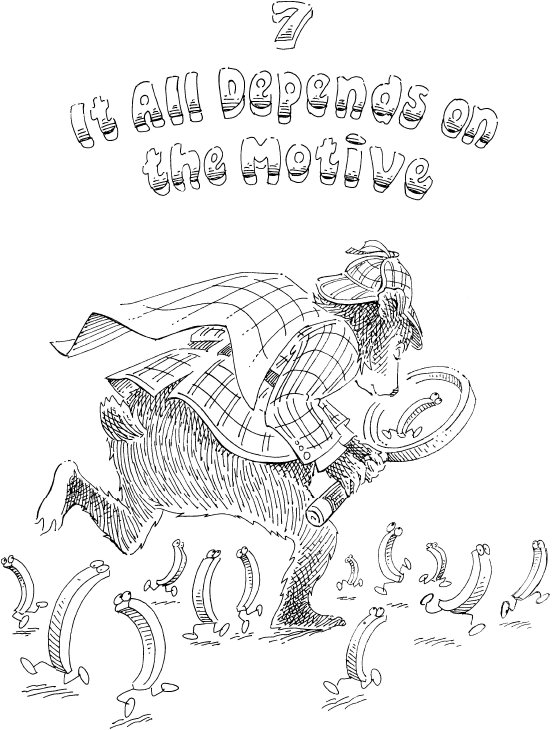

| Our mushroom pot pie requires quite a few peas. Now it is time to define *peas*, which produces as many peas as required. What type expresses this behavior? | <sup>1</sup> | The type is (→ Nat (List Atom)) because *peas* should be able to produce any number of peas. |
| --- | --- | --- |
| How many peas should *peas* produce? | <sup>2</sup> | It depends. |
| What does it depend on? | <sup>3</sup> | It depends on how many peas are required—that is, the argument. |
| The type in frame 1, (→ Nat (List Atom)), is not specific enough. It does not express that *peas* produces *precisely* as many peas as were asked for. | <sup>4</sup> | The number of peas is the Nat argument. Does this type do the trick? (**claim *peas*** (Π ((*how-many-peas* Nat)) (Vec Atom *how-many-peas*))) |
| Yes, and the type expresses that the number of peas as the argument to *peas* depends on the number asked for. Such types are called *dependent types*. Can *peas* be written using **rec-Nat**? | <sup>5</sup> | Sure. (**define *peas*** (λ (*how-many-peas*) (**rec-Nat** *how-many-peas* vecnil (λ (*ℓ-1* *peas*<sub>*ℓ-1*</sub>) (vec:: **'**pea *peas*<sub>*ℓ-1*</sub>))))) |

**Dependent Types**

**A type that is determined by something that is not a type is called a *dependent type*.**

| The definition of *peas* is not an expression. To use **rec-Nat**, the base must have the same type as the *peas<sub>ℓ-1</sub>* argument to the step. Here, though, the *peas<sub>ℓ-1</sub>* might be a … | <sup>6</sup> | What about **iter-Nat**? |
| --- | --- | --- |
| **rec-Nat** can do anything that **iter-Nat** can. | <sup>7</sup> | Is there something more powerful to use? |
| It is called **ind-Nat**, short for “induction on Nat.” | <sup>8</sup> | What is **ind-Nat**? |
| **ind-Nat** is like **rec-Nat**, except it allows the types of the base and the almost-answer in the step, here *peas<sub>ℓ-1</sub>*, to include the target Nat. In other words, **ind-Nat** is used for… | <sup>9</sup> | There is a Nat called *how-many-peas* included in (Vec Atom *how-many-peas*). Is this a dependent type? |
| Yes, it depends on the Nat *how-many-peas*. To work with dependent types, **ind-Nat** needs an extra argument: to use **ind-Nat**, it is necessary to state *how* the types of both the base and the ste… | <sup>10</sup> | What does this extra argument look like? |
| This extra argument, called the *motive*,† can be any (→ Nat *U*). An **ind-Nat**-expression’s type is the motive applied to the target Nat. _______________ †Thanks, Conor McBride (1973–). | <sup>11</sup> | So the motive is a function whose body is a *U*. |
| It is. The motive explains *why* the target is to be eliminated. What is the motive for *peas*? | <sup>12</sup> | That’s a good question. At least its type is clear. (**claim *mot-peas***† (→ Nat *U*)) _______________ †“mot” is pronounced “moat.” |

**Use ind-Nat for Dependent Types**

**Use ind-Nat instead of rec-Nat when the rec-Nat- or ind-Nat-expression’s type depends on the target** Nat**. The ind-Nat-expression’s type is the motive applied to the target.**

| Here is *mot-peas*. (**define *mot-peas*** (λ (*k*) (Vec Atom *k*))) What is the value of (*mot-peas* zero)? | <sup>13</sup> | It is the *U*, and thus also the type, (Vec Atom zero). |
| --- | --- | --- |
| What type must the base for *peas* have? | <sup>14</sup> | Surely it must have the type (Vec Atom zero), because the value of the base is the value when zero is the target. |
| What should the base for *peas* be? | <sup>15</sup> | It must be vecnil because vecnil is the only (Vec Atom zero). |
| This is also (*mot-peas* zero). What is the purpose of a step in **rec-Nat**? | <sup>16</sup> | In **rec-Nat**, the step’s arguments are *n-1* and the almost-answer, which is the value from eliminating *n-1*. Given *n-1* and the almost-answer, the step determines the value for (add1 *n-1*). |
| The step’s arguments in **ind-Nat** are also *n-1* and an almost-answer. What is the almost-answer’s type? | <sup>17</sup> | The almost-answer’s type is the motive applied to *n-1* because the almost-answer is the value for the target *n-1*. |
| What is the type of the value for the target (add1 *n-1*)? | <sup>18</sup> | The type of an **ind-Nat**-expression is the motive applied to the target. |
| If the motive is called *mot*, then the step’s type is (Π ((*n-1* Nat)) (→ (*mot n-1*) (*mot* (add1 *n-1*)))). | <sup>19</sup> | What is an example of a step for **ind-Nat**? |
| Here is the step for *peas*. (**claim *step-peas*** (Π ((*ℓ**-1* Nat)) (→ (*mot-peas* *ℓ-1*) (*mot-peas* (add1 *ℓ-1*))))) (**define *step-peas*** (λ (*ℓ-1*) (λ (*peas<sub>ℓ-1</sub>*) (vec:: **'**pea *… | <sup>20</sup> | Why does *mot-peas* appear twice in *step-peas*’s type? |
| Good question. What is the value of (**mot-peas** ℓ-1)? | <sup>21</sup> | It is (Vec Atom *ℓ-1*). |

**The Law of ind-Nat**

**If** *target* **is a** Nat**,** *mot* **is an**

**(**→ Nat

*U***)**,

*base* **is a (***mot* zero**), and** *step* **is a**

**(Π ((***n-1* Nat**))**

**(**→ **(***mot n-1***)**

**(***mot* **(**add1 *n-1***))))**,

**then**

**(ind-Nat** *target*

*mot*

*base*

*step***)**

**is a (***mot target***).**

**The First Commandment of ind-Nat**

**The ind-Nat-expression**

**(****ind-Nat** zero

*mot*

*base*

*step***)**

**is the same (***mot* zero**) as** *base***.**

**The Second Commandment of ind-Nat**

**The ind-Nat-expression**

**(ind-Nat (**add1 *n***)**

*mot*

*base*

*step***)**

**and**

**(***step n*

**(ind-Nat** *n*

*mot*

*base*

*step***))**

**are the same (***mot* **(**add1 *n***)).**

| This is *peas<sub>ℓ-1</sub>*’s type, which describes a list containing *ℓ-1* peas. What is the value of (*mot-peas* (add1 *ℓ-1*)), and what does it mean? | <sup>22</sup> | It is (Vec Atom (add1 *ℓ-1*)), which describes a list containing (add1 *ℓ-1*) peas. |
| --- | --- | --- |

**Induction on Natural Numbers**

**Building a value for any natural number by giving a value for zero and a way to transform a value for** *n* **into a value for** *n* + 1 **is called *induction on natural numbers*.**

The step must construct a value for (add1 *ℓ-1*) from a value for *ℓ-1*.

Look at *step-peas*’s type again. What does it mean in prose?

<sup>23</sup>

No matter what Nat *ℓ-1* is, *step-peas* can take a

(Vec Atom *ℓ-1*)

and produce a

(Vec Atom (add1 *ℓ-1*)).

It does this by “consing” a **'**pea to the front.

The base replaces

zero

with

vecnil

because

vecnil

is the only

(Vec Atom zero).

What does *step-peas* replace an add1 with?

<sup>24</sup>

*step-peas* replaces each add1 with a vec::, just as *length* in frame 5:34 replaces each :: in a list with add1.

Now it is possible to define *peas*, using *mot-peas* and *step-peas*.

<sup>25</sup>

Here is the definition.

(**define *peas***

(λ (*how-many-peas*)

(**ind-Nat** *how-many-peas*

*mot-peas*

vecnil

*step-peas*)))

What is the value of (*peas* 2)?

Here are the first two steps.

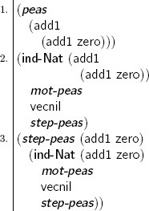

Now, find its value. Remember that arguments need not be evaluated.

<sup>26</sup>

And finally, we find its normal form,

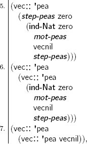

which is normal.

If the motive’s argument is dim, then **ind-Nat** works just like **rec-Nat**. Define a function *also-rec-Nat* using **ind-Nat** that works just like **rec-Nat**.

(**claim *also-rec-Nat***

(Π ((*X U*))

(→ Nat

*X*

(→ Nat *X*

*X*)

*X*)))

<sup>27</sup>

The type does not depend on the target, so *k* is dim.

(**define *also-rec-Nat***

(λ (*X*)

(λ (*target base step*)

(**ind-Nat** *target*

(λ (*k*)

*X*)

*base*

*step*))))

Just as *first* finds the first entry in a list, *last* finds the last entry.

What type should *last* have?

<sup>28</sup>

The list must be non-empty, which means that we can use the same idea as in *first*’s type.

(**claim *last***

(Π ((*E U*)

(*ℓ* Nat))

(→ (Vec *E* (add1 *ℓ*))

*E*)))

If a list contains only one Atom, which Atom is the last one?

<sup>29</sup>

There is only one possibility.

What is the normal form of

(*last* Atom zero

(vec:: **'**flour vecnil))?

<sup>30</sup>

Here is a guess. The question has no meaning, because that list contains one rather than zero entries.

What is (*last* Atom zero)’s type?

Remember Currying.

<sup>31</sup>

(*last* Atom zero)’s type is

(→ (Vec Atom (add1 zero))

Atom).

So the question in the preceding frame does, in fact, have a meaning!

What is the normal form of

(*last* Atom zero

(vec:: **'**flour vecnil))?

<sup>32</sup>

It must be **'**flour.

Yes, indeed.

Using this insight, what is *base-last*’s type?

<sup>33</sup>

The base is used when the Nat is zero.

(**claim *base-last***

(Π ((*E U*))

(→ (Vec *E* (add1 zero))

*E*)))

What is the definition of *base-last*?

<sup>34</sup>

It uses **head** to obtain the only entry in a

(Vec Atom (add1 zero)).

(**define *base-last***

(λ (*E*)

(λ (*es*)

(**head** *es*))))

This is the first time that the base is a function. According to the motive, both the base and the step’s almost-answer are functions.

When the base is a function and the step transforms an almost-function into a function, the **ind-Nat**-expression constructs a function as well.

<sup>35</sup>

Are λ-expressions values?

Yes, because λ is a constructor.

<sup>36</sup>

Functions are indeed values.

The **ind-Nat**-expression’s type is the motive applied to the target, which is the Nat being eliminated.

What is the target Nat when the base is reached?

<sup>37</sup>

It is zero. That is what it means to be the base.

The motive applied to zero should be the base’s type.

Find an expression that can be used for the motive.

<sup>38</sup>

How about

(Π ((*E U*)

(*k* Nat))

(→ (Vec *E* (add1 *k*))

*E*))?

Filling in *E* with the entry type and *k* with zero yields the base’s type.

**ind-Nat’s Base Type**

**In ind-Nat, the base’s type is the motive applied to the target** zero**.**

| That’s close, but not quite correct. The motive for **ind-Nat** should be applied to zero, but applying a Π-expression doesn’t make sense. The motive for **ind-Nat** is a function, not a function’s ty… | <sup>39</sup> | Oh, so it must be (λ (*E k*) (→ (Vec *E* (add1 *k*)) *E*)), which can be applied to the entry type and zero to obtain the base’s type. |
| --- | --- | --- |
| Now define the motive for *last*. (**claim *mot-last*** (→ *U* Nat *U*)) | <sup>40</sup> | Here it is. (**define *mot-last*** (λ (*E k*) (→ (Vec *E* (add1 *k*)) *E*))) |
| What is the type and value of (*mot-last* Atom)? | <sup>41</sup> | The type is (→ Nat *U*) and the value is (λ (*k*) (→ (Vec Atom (add1 *k*)) Atom)). |
| What does this resemble? | <sup>42</sup> | *twin-Atom* from frame 4:54. Applying *mot-last* to a *U* results in a suitable motive for **ind-Nat**. |
| What is the value of the base’s type, which is (*mot-last* Atom zero)? | <sup>43</sup> | It is the type (→ (Vec Atom (add1 zero)) Atom). |
| What is the value of (*mot-last* Atom (add1 *ℓ-1*))? | <sup>44</sup> | It is (→ (Vec Atom (add1 (add1 *ℓ-1*))) Atom). |
| What is the purpose of the step for *last*? | <sup>45</sup> | The step for *last* turns the almost-answer for *ℓ-1* into the answer for (add1 *ℓ-1*). In other words, the step for *last* changes a function that gets the last entry in a (Vec *E* (add1 *ℓ-1*)) to a… |
| The outer add1 is part of the type in order to ensure that the list given to *last* has at least one entry. The inner add1 is from the (add1 *ℓ-1*) passed to *mot-last*. | <sup>46</sup> | The outer add1 makes the function total, and the inner add1 is due to the Law of **ind-Nat**. |
| What is the step’s type? | <sup>47</sup> | The step’s type must be (→ (→ (Vec *E* (add1 *ℓ-1*)) *E*) (→ (Vec *E* (add1 (add1 *ℓ-1*))) *E*)) because the step must construct a (**mot-last** E (add1 *ℓ-1*)) from a (**mot-last** E *ℓ-1*). |
| How can that type be explained in prose? | <sup>48</sup> | The step transforms a *last* function for *ℓ* into a *last* function for (add1 *ℓ*). |

**ind-Nat’s Step Type**

**In ind-Nat, the step must take two arguments: some** Nat *n* **and an almost-answer whose type is the motive applied to** *n***. The type of the answer from the step is the motive applied to (**add1 *n***). The step’s type is:**

**(Π ((***n* Nat**))**

**(**→ **(***mot n***)**

**(***mot* **(**add1 *n***))))**

Here is *step-last*’s claim.

(**claim *step-last***

(Π ((*E U*)

(*ℓ**-1* Nat))

(→ (*mot-last* E *ℓ-1*)

(**mot-last** E (add1 *ℓ-1*)))))

Now define *step-last*.

<sup>49</sup>

*last<sub>ℓ-1</sub>* is almost the right function, but only for a list with (add1 *ℓ-1*) entries, so it accepts the **tail** of a list with

(add1

(add1 *ℓ-1*))

entries as an argument.

(**define *step-last***

(λ (*E ℓ-1*)

(λ (*last<sub>ℓ-1</sub>*)

(λ (*es*)

(*last<sub>ℓ-1</sub>* (**tail** *es*))))))

What is *es*’s type in the inner λ-expression?

<sup>50</sup>

*es* is a

(Vec *E* (add1

(add1 *ℓ-1*))).

Why is that *es*’s type?

<sup>51</sup>

The whole inner λ-expression’s type is

(**mot-last** E (add1 *ℓ-1*)),

and that type and

(→ (Vec *E* (add1

(add1 *ℓ-1*)))

*E*)

are the same type. Thus, the argument to the λ-expression, namely *es*, is a

(Vec *E* (add1

(add1 *ℓ-1*))).

Clever.

What is (**tail** *es*)’s type?

<sup>52</sup>

(**tail** *es*)’s type is

(Vec *E* (add1 *ℓ-1*)),

which is the type of a suitable argument for the almost-ready function.

What is *last<sub>ℓ-1</sub>*’s type in the outer λ-expression in frame 49?

<sup>53</sup>

*last<sub>ℓ-1</sub>* is an

(→ (Vec *E* (add1 *ℓ-1*))

*E*),

which is the value of (**mot-last** E *ℓ-1*).

Now it is time to define *last*. The **claim** is in frame 28 on page 151.

<sup>54</sup>

Here goes.

(**define *last***

(λ (*E ℓ*)

(**ind-Nat** *ℓ*

(**mot-last** E)

(**base-last** E)

(**step-last** E))))

What is the normal form of

(*last* Atom 1

(vec:: **'**carrot

(vec:: **'**celery vecnil)))?

Here is the beginning.

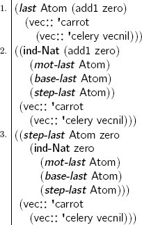

<sup>55</sup>

Thanks for the help. There is more.

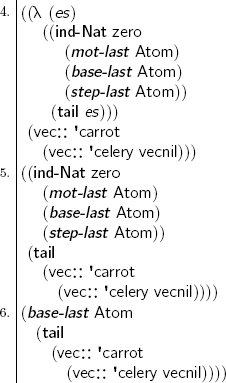

Is that the normal form?

<sup>56</sup>

No, there are a few more steps.

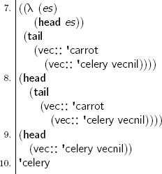

Excellent.

Now take a quick break and have some fortifying mushroom pot pie.

<sup>57</sup>

That sounds like a good idea.

Guess what *drop-last* means.

<sup>58</sup>

Presumably, it drops the last entry in a Vec.

Good guess!

What is (*drop-last* Atom 3 vecnil)?

<sup>59</sup>

It is not described by a type, for the same reason that

(*first* Atom 3 vecnil),

(*last* Atom 3 vecnil),

and

(*rest* Atom 3 vecnil)

aren’t described by types.

The type must contain a Vec with an add1 in it.

That’s solid thinking.

What is *drop-last*’s type?

<sup>60</sup>

*drop-last* shrinks a list by one.

(**claim *drop-last***

(Π ((*E U*)

(*ℓ* Nat))

(→ (Vec *E* (add1 *ℓ*))

(Vec *E* *ℓ*))))

What is *base-drop-last*?

<sup>61</sup>

The base finds the

*drop-last*

of a single-entry list, which is

vecnil

because the last entry is the only entry.

(**claim *base-drop-last***

(Π ((*E U*))

(→ (Vec *E* (add1 zero))

(Vec *E* zero))))

(**define *base-drop-last***

(λ (*E*)

(λ (*es*)

vecnil)))

Would this definition of *base-drop-last* also work?

(**define *base-drop-last***

(λ (*E*)

(λ (*es*)

(**tail** *es*))))

<sup>62</sup>

It always has the same value, but it does not convey the idea as clearly.

The intention is that *base-drop-last* ignores the last entry in the list.

That sounds right.

Why doesn’t it deserve a solid box?

<sup>63</sup>

Getting the right answer is worthless if we do not *know* that it is correct. Understanding the answer is at least as important as having the correct answer.

**Readable Expressions**

**Getting the right answer is worthless if we do not *know* that it is correct. Understanding the answer is at least as important as having the correct answer.**

Someone has been paying attention!

What is *mot-drop-last*?

<sup>64</sup>

*mot-drop-last* says that *drop-last* constructs a Vec with one fewer entries.

(**claim *mot-drop-last***

(→ *U* Nat

*U*))

(**define *mot-drop-last***

(λ (*E k*)

(→ (Vec *E* (add1 *k*))

(Vec *E k*))))

That was fast. Please explain.

<sup>65</sup>

During **ind-Nat**, the motive applied to zero is the base’s type. That means that we can work backwards by replacing the zeros in the base’s type with the argument *k* to *mot-drop-last* in the base’s type from frame 61.

That is a keen observation. This approach does not always work, but it is a good starting point.

Replacing a particular constant with a variable and wrapping a λ of the variable is called *abstracting over constants*, and it is used often. Here, the motive abstracts over zero in *base-drop-last*.

<sup>66</sup>

*step-drop-last*’s type follows the Law of **ind-Nat**.

(**claim *step-drop-last***

(Π ((*E U*)

(*ℓ**-1* Nat))

(→ (**mot-drop-last** E ℓ-1)

(**mot-drop-last** E (add1 *ℓ-1*)))))

How should *step-drop-last* be defined?

<sup>67</sup>

*step-drop-last* keeps the head around.

(**define *step-drop-last***

(λ (*E ℓ-1*)

(λ (*drop-last<sub>ℓ-1</sub>*)

(λ (*es*)

(vec:: (**head** *es*)

(*drop-last<sub>ℓ-1</sub>* (**tail** *es*)))))))

This is the familiar pattern of induction:

*step-drop-last*

transforms a

*drop-last*

that works for

(Vec *E*

(add1 *ℓ-1*))

into a

*drop-last*

that works for

(Vec *E*

(add1

(add1 *ℓ-1*))).

How does the transformation work?

<sup>68</sup>

Just as

*step-last*

uses its almost-answer, namely *last<sub>ℓ-1</sub>*, to find the *last* of its own (**tail** *es*),

*step-drop-last*

uses its almost-answer, *drop-last<sub>ℓ-1</sub>*, to find the *drop-last* of its own (**tail** *es*).

Based on *mot-drop-last*, the function produced by *step-drop-last* must add an entry to that list. Thus, the inner λ-expression in frame 67 “cons”es (using vec::) the **head** of *es* onto the (*drop-last<sub>ℓ-1</sub>* (**tail** *es*)).

The **claim** for *drop-last* is in frame 60 on page 159.

Now define *drop-last*.

<sup>69</sup>

It’s a matter of putting the pieces together.

(**define *drop-last***

(λ (*E ℓ*)

(**ind-Nat** *ℓ*

(**mot-drop-last** E)

(**base-drop-last** E)

(**step-drop-last** E))))

Yes, *drop-last* is now defined.

Sometimes, it can be convenient to find a function that can be used later. For example, (*drop-last* Atom 2) finds the first two entries in any three-entry list of Atoms.

Show how this works by finding the value of

(*drop-last* Atom

(add1

(add1 zero))).

<sup>70</sup>

Here’s the chart to find the value.

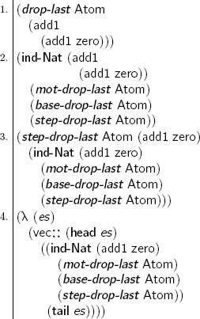

That’s right—λ-expressions are values. To find the normal form, more steps are necessary. Here’s the first one.

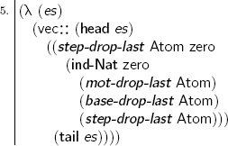

Now find the normal form.

<sup>71</sup>

In step 6, *es* has been consistently renamed to *ys* to make it clear that the inner λ-expression has its own variable.

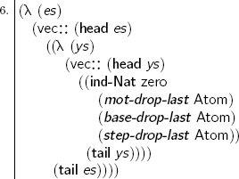

It is not necessary to rename *es* to *ys*, because variable names always refer to their closest surrounding λ, but it’s always a good idea to make expressions easier to understand.

Here are two more steps.

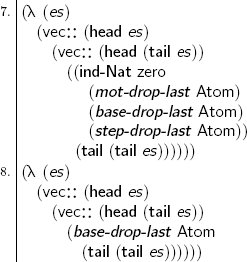

<sup>72</sup>

Almost there.

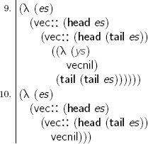

The normal form is much easier to understand than the starting expression!

*C’est magnifique!* Bet you’re tired.

<sup>73</sup>

Indeed. And hungry, too.

**Eat the rest of that pot pie,**

**and head to a café if you’re still hungry, and re-read this chapter in a relaxed ambience.**

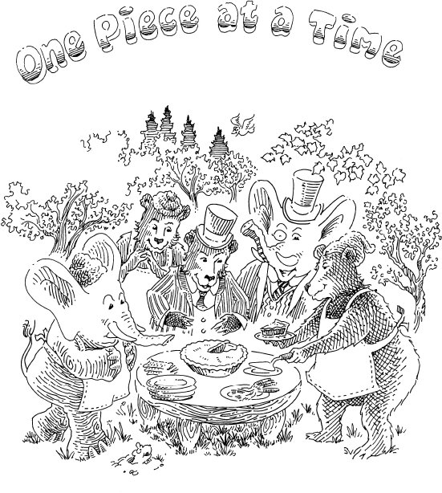

Sometimes, it is not immediately apparent how to write a Pie expression.

<sup>1</sup>

That’s what empty boxes are for, right?

That’s right. Most keyboards, however, do not make it particularly easy to type empty boxes.

Instead of typing empty boxes, it is possible to leave part of an expression to be written later using the TODO form.

<sup>2</sup>

What is TODO?

TODO is an expression that is a placeholder for another expression. A TODO can have any type, and Pie keeps track of which TODOs have which types.

<sup>3</sup>

How can TODO be used?

Each TODO comes from somewhere specific. Here, we refer to them by frame number; when using Pie outside of a book, this will be somewhere else that is appropriate.

Try typing

(claim peas

TODO)

and see what happens.

<sup>4</sup>

Pie responds with

Frame 4:2.3: TODO: U

and the TODO it’s mentioning is indeed a *U* on the second line and third column of an expression in frame 4.

Now try

(claim peas

(Pi ((n Nat))

TODO))

which is closer to the type for *peas* in chapter 7.

<sup>5</sup>

Pie responds with

Frame 5:3.5: TODO:

n : Nat

--------------

U

but what does that horizontal line mean?

When Pie replies with the type that is expected for a TODO, it also includes the types of the variables that can be used at the TODO’s position.

<sup>6</sup>

The n : Nat above the line means that the variable *n* is a Nat.

That’s right.

Now try

(claim peas

(Pi ((n Nat))

(Vec Atom n)))

(define peas

TODO)

where the TODO is in a definition.

<sup>7</sup>

Pie replies with

Frame 7:5.3: TODO:

(Π ((n Nat))

(Vec Atom n))

which is the type that was **claim**ed.

How does Pie respond when provided with a λ around the TODO?

(claim peas

(Pi ((n Nat))

(Vec Atom n)))

(define peas

(λ (n)

TODO))

<sup>8</sup>

There will be a line for n above the horizontal line.

Try it and see.

<sup>9</sup>

That’s what happened.

Frame 8:6.5: TODO:

n : Nat

--------------

(Vec Atom n)

What’s next?

<sup>10</sup>

The number of **'**peas depends on *n*, so **ind-Nat** is needed.

How does Pie respond to this version of *peas*?

(claim peas

(Pi ((n Nat))

(Vec Atom n)))

(define peas

(λ (n)

(ind-Nat n

(λ (k)

(Vec Atom k))

TODO

TODO)))

<sup>11</sup>

Each TODO has the type that would be expected by the Law of **ind-Nat**.

Frame 11:9.7: TODO:

n : Nat

--------------

(Vec Atom 0)

Frame 11:10.7: TODO:

n : Nat

--------------

(Π ((n-1 Nat))

(→ (Vec Atom n-1)

(Vec Atom

(add1 n-1))))

How should the TODOs be replaced?

<sup>12</sup>

The first TODO should be a (Vec Atom 0), so vecnil is appropriate. The second TODO should be a two-argument function, built with λ, that uses vec:: to add a **'**pea to *n-1* peas.

Nicely chosen. How does Pie respond to this version?

(claim peas

(Pi ((n Nat))

(Vec Atom n)))

(define peas

(λ (n)

(ind-Nat n

(λ (k)

(Vec Atom k))

vecnil

(λ (n-1 peas-of-n-1)

(vec:: TODO TODO)))))

<sup>13</sup>

The Law of vec:: determines the type of each TODO.

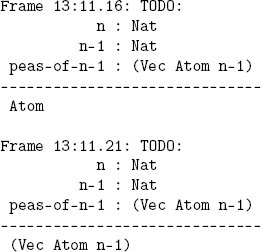

Now replace the final TODOs.

<sup>14</sup>

Here is the final definition.

(claim peas

(Pi ((n Nat))

(Vec Atom n)))

(define peas

(λ (n)

(ind-Nat n

(λ (k)

(Vec Atom k))

vecnil

(λ (n-1 peas-of-n-1)

(vec:: 'pea

peas-of-n-1)))))

**Go eat a mushroom pot pie that contains n peas,**

**one delicious bite at a time.**

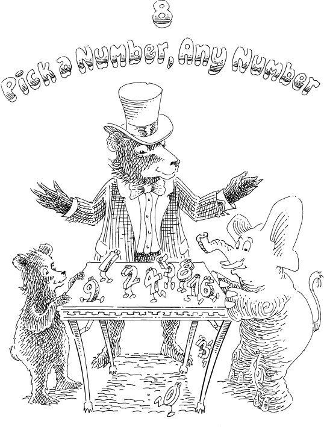

How was that mushroom pot pie?

<sup>1</sup>

Delicious, though very filling. How about something less filling here?

How about a

(*sandwich* 'hoagie)?

<sup>2</sup>

That should be manageable.

What is the normal form of (**+** 1)?

<sup>3</sup>

Let’s find out.

Let’s start.

<sup>4</sup>

The normal form needs a bit more work.

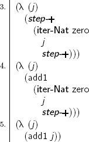

Here is another definition.

(**claim *incr***

(→ Nat

Nat))

(**define *incr***

(λ (*n*)

(**iter-Nat** *n*

1

(**+** 1))))

What is the normal form of (*incr* 0)?

<sup>5</sup>

That’s just three steps.

It is 1, also known as (add1 zero).

What is the normal form of (*incr* 3)?

<sup>6</sup>

That is indeed the value. But what is the normal form? Here’s a few more steps.

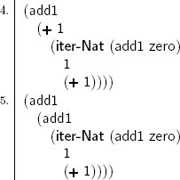

<sup>7</sup>

The normal form is 4.

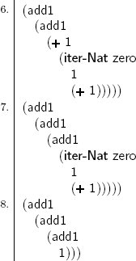

What is the relationship between

(**+** 1)

and

*incr*?

<sup>8</sup>

They both find the same answer, no matter what the argument is.

Does this mean that (**+** 1) is the same

(→ Nat

Nat)

as *incr*?

<sup>9</sup>

They are the same if they have the same normal form.

The normal form of (**+** 1) is

(λ (*n*)

(add1 *n*)),

while the normal form of *incr* is

(λ (*n*)

(**iter-Nat** *n*

1

(λ (*j*)

(add1 *j*)))).

They are not the same.

That’s right.

Even though they are not the same, the fact that they always find the same answer can be written as a type.

<sup>10</sup>

But isn’t sameness a judgment, not a type?

Sameness is indeed a judgment. But, with a new type constructor, types can express a new idea called *equality*.

Writing

“*incr* and (**+** 1) always find the same answer.”

as a type is hungry work. You’d better have this

(*sandwich* 'grinder)

to keep your energy up.

<sup>11</sup>

Another sandwich?

Okay.

An expression

(**=** *X from to*)

is a type if

*X*

is a type,

*from*

is an *X*, and

*to*

is an *X*.

<sup>12</sup>

Is this another way to construct a dependent type?

**The Law of =**

**An expression**

**(=** *X from to***)**

**is a type if** *X* **is a type,** *from* **is an** *X***, and** *to* **is an** *X***.**

| Yes, **=** is another way to construct a dependent type, because *from* and *to* need not be types. Because *from* and *to* are convenient names, the corresponding parts of an **=**-expression are cal… | <sup>13</sup> | Okay. |
| --- | --- | --- |

**Reading** FROM **and** TO **as Nouns**

**Because** *from* **and** *to* **are convenient names, the corresponding parts of an **=**-expression are referred to as the** FROM **and the** TO**.**

| Is (**=** Atom **'**kale **'**blackberries) a type? | <sup>14</sup> | Yes, because Atom is a type and both **'**kale and **'**blackberries are Atoms. |
| --- | --- | --- |
| Is (**=** Nat (**+** 1 1) 2)† a type? _______________ †Thank you, Alfred North Whitehead (1861–1947) and again Bertrand Russell. Page 379 of *Principia Mathematica*, their 3-volume work published resp… | <sup>15</sup> | Yes, because Nat is a type and both (**+** 1 1) and 2 are Nats. |
| Is (**=** (**car** (cons Nat **'**kale)) 17 (**+** 14 3)) a type? | <sup>16</sup> | Yes, it is, because (**car** (cons Nat **'**kale)) and Nat are the same type, and the FROM and the TO are both Nats. |
| Is (**=** (**car** (cons Nat **'**kale)) 15 (**+** 14 3)) a type? | <sup>17</sup> | Yes, it is. Frame 12 requires only that the FROM and the TO are Nats, not that they are the same Nat. But what is the purpose of **=**? |
| To understand **=**, it is first necessary to gain a new perspective on types. Types can be read as *statements*.† _______________ †Thank you Robert Feys (1889–1961), Nicolaas Govert de Bruijn (1918–2… | <sup>18</sup> | How can (**=** Atom **'**apple **'**apple) be read as a statement? |
| The type (**=** Atom **'**apple **'**apple) can be read: “The expressions **'**apple and **'**apple are equal Atoms.” How can (**=** Nat (**+** 2 2) 4) be read as a statement? | <sup>19</sup> | Does “Two plus two equals four” make sense? |
| Yes, it does. | <sup>20</sup> | In what way do “Three plus four equals seven” and (**+** 3 4) is the same Nat as 7 differ? |
| The statement “Three plus four equals seven” is another way of writing the type (**=** Nat (**+** 3 4) 7), which *is* an expression, but (**+** 3 4) is the same Nat as 7 is a judgment *about* expressi… | <sup>21</sup> | Here’s a judgment: “Three plus four equals seven” is a type. |
| Well-spotted. **=**-expressions are not the only types that can be read as statements. | <sup>22</sup> | What are some others? |
| A Π-expression can be read as “for every.” Consider this example, (Π ((*n* Nat)) (**=** Nat (**+** 1 *n*) (add1 *n*))) can be read as “For every Nat *n*, (**+** 1 *n*) equals (add1 *n*).” | <sup>23</sup> | Okay. But what is the point of reading types as statements? |
| If a type can be read as a statement, then judging the statement to be true means that there is an expression with that type. So, saying “(**+** *n* 0) and *n* are equal Nats.” means “There is an expr… | <sup>24</sup> | Does this mean that truth requires evidence? |
| It goes further. Truth *means* that we have evidence.† This evidence is called a *proof*. _______________ †Thank you, BHK: L. E. J. Brouwer (1881–1966), Arend Heyting (1898–1980), and Andrey Kolmogoro… | <sup>25</sup> | Can every type be read as a statement? |
| In principle, they could be, but many types would be very uninteresting as statements. | <sup>26</sup> | What makes a statement interesting? |
| A person does, by being interested in it. But most interesting statements come from dependent types. Nat is not an interesting statement because it is too easy to prove. | <sup>27</sup> | How can Nat be proved? |
| Pick a number, any number. | <sup>28</sup> | Okay, 15. |
| Good job. You have a proof. | <sup>29</sup> | That isn’t very interesting. |
| Right. | <sup>30</sup> | That explains it. |
| Another way to think about statements is as an expectation of a proof, or as a problem to be solved. | <sup>31</sup> | Having seen a **claim**, it makes sense to expect a definition. |
| Frame 12 describes when an **=**-expression is a type, but it says nothing about what the values of such a type are. | <sup>32</sup> | Here, “values” means the same thing as “proofs,” right? |
| Exactly right. There is only one constructor for **=**, and it is called same. same takes one argument. | <sup>33</sup> | How is same used? |
| The expression (same *e*) is an (**=** *X e e*) if *e* is an *X*. | <sup>34</sup> | What is an example of this? |

**The Law of** same

**The expression (**same *e***) is an (=** *X e e***) if** *e* **is an** *X***.**

The expression

(same 21)

is an

(**=** Nat (**+** 17 4) (**+** 11 10)).

<sup>35</sup>

That doesn’t seem right.

In frame 34, same’s argument as well as the FROM and TO arguments of **=** have to be identical, but here, 21,

(**+** 17 4)

and

(**+** 11 10)

look rather different.

Both

(**+** 17 4)

and

(**+** 11 10)

are the same Nat as 21, so they are the same.

<sup>36</sup>

Does this mean that

(same (*incr* 3))

is an

(**=** Nat (**+** 2 2) 4)?

Yes,

(same (*incr* 3))

is a proof of

(**=** Nat (**+** 2 2) 4).

The Law of same uses *e* twice to require that

the FROM is the same *X* as the TO.

With the type constructor **=** and its constructor same, expressions can now state ideas that previously could only be judged.†

_______________

†Creating expressions that capture the ideas behind a form of judgment is sometimes called *internalizing* the form of judgment.

<sup>37</sup>

Why is this so important?

Expressions can be used together with other expressions.

By combining Π with **=**, we can write statements that are true for arbitrary Nats, while we could only make judgments about particular Nats. Here’s an example:

(**claim *+1=add1***

(Π ((*n* Nat))

(**=** Nat (**+** 1 *n*) (add1 *n*))))

<sup>38</sup>

The definition of *+1=add1* clearly has a λ at the top because its type has a Π at the top.

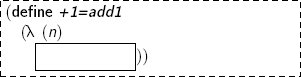

That’s a solid start. What goes in the box?

<sup>39</sup>

Following the Law of λ,

(**=** Nat (**+** 1 *n*) (add1 *n*))

is the type of the body of the λ-expression.

Right, the box should contain an

(**=** Nat (**+** 1 *n*) (add1 *n*)).

What is the normal form of the box’s type?

<sup>40</sup>

The normal form of the box’s type is

(**=** Nat (add1 *n*) (add1 *n*))

because the normal form of

(**+** 1 *n*)

is

(add1 *n*).

Okay, so the expression in the box in frame 38 is

(same (add1 *n*)).

That’s right.

Now finish the definition.

<sup>41</sup>

Here it is.

(**define *+1=add1***

(λ (*n*)

(same (add1 *n*))))

What statement does *+1=add1* prove?

<sup>42</sup>

The statement is

“For every Nat *n*, (**+** 1 *n*) equals (add1 *n*).”

Here is another statement.

“For every Nat *n*, (*incr* *n*) is equal to (add1 *n*).”

Translate it to a type.

<sup>43</sup>

Let’s call it *incr=add1*.

(**claim *incr=add1***

(Π ((*n* Nat))

(**=** Nat (**incr** n) (add1 *n*))))

Now define *incr=add1*.

<sup>44</sup>

Isn’t it just like *+1=add1*?

(**define *incr=add1***

(λ (*n*)

(same (add1 *n*))))

Not quite. What is the normal form of

(**incr** n)?

<sup>45</sup>

The normal form is *not* the same Nat as (add1 *n*).

That’s right. This normal form is neutral.

What is a neutral expression?

<sup>46</sup>

Neutral expressions are described in frame 2:24 on page 39.

Neutral expressions are those that cannot yet be evaluated.

Why is

(**iter-Nat** *n*

1

(**+** 1))

neutral?

<sup>47</sup>

Because **iter-Nat** chooses the base when the target is zero, or the step when the target has add1 at the top. But *n* is neither.

A more precise way to define *neutral expressions* is to start with the simplest neutral expressions and build from there.

Variables are neutral, unless they refer to definitions, because a defined name is the same as its definition (see page 43).

<sup>48</sup>

Okay.

Also, if the target of an eliminator expression is neutral, then the entire expression is neutral.

<sup>48</sup>

So,

(**iter-Nat** *n*

1

(**+** 1))

is neutral because **iter-Nat** is an eliminator and its target, *n*, is a variable.

Is every expression that contains a variable neutral?

**Neutral Expressions**

**Variables that are not defined are neutral. If the target of an eliminator expression is neutral, then the eliminator expression is neutral. Thus, values are not neutral.**

| No. The body of the λ-expression (λ (*x*) (add1 *x*)) contains the variable *x*, but λ-expressions are values, not neutral expressions. | <sup>50</sup> | Even if the *whole* expression were just (add1 *x*), it would not be neutral because it would have add1 at the top and therefore be a value. Are neutral expressions normal? |
| --- | --- | --- |
| Not always. Some types have ways of making neutral expressions into values, and in these cases, the neutral expression is not considered normal, because it can be made into a value. | <sup>51</sup> | Which types work this way? |
| A neutral expression whose type has Π at the top is not normal. This is because a neutral expression *f* is the same as (λ (*x*) (*f x*)), which is a value. | <sup>52</sup> | Why does this mean that *f* is not normal? |
| What does it mean for an expression to be normal? | <sup>53</sup> | The big box on page 13 states that if two expressions are the same, then they have identical normal forms. |
| By the Second Commandment of λ† on page 140, *f* is the same as (λ (*x*) (*f x*)), but they are *not* written identically. _______________ †Commandments such as this one are often called η- (pronounce… | <sup>54</sup> | One is wrapped in a λ, the other is not. |
| At most one of them can be the normal form. The one wrapped in λ is the normal form. Because expressions with λ at the top are values, they are not neutral. Neutral expressions do not have a construct… | <sup>55</sup> | Are there any others? |
| Yes. Because of the Second Commandment of cons from page 44, if *p* is a (Pair *A D*), then *p* is the same as (cons (**car** *p*) (**cdr** *p*)). For the very same reason, the only normal forms for p… | <sup>56</sup> | Where do neutral expressions come from? |
| Neutral expressions, like (**incr** n)’s normal form in frame 45, occur frequently when **=**-expressions mention argument names in Π-expressions. | <sup>57</sup> | How can we find a definition for *incr=add1*? same does not do the job, after all, and *incr=add1*’s type has a neutral expression in it. |
| Judgments, like (**incr** n) is the same Nat as (add1 *n*), can be mechanically checked using relatively simple rules. This is why judgments are a suitable basis for knowledge. Expressions, however, c… | <sup>58</sup> | Does this mean that induction can be used to prove that (**incr** n) and (add1 *n*) are equal, even though they are not the same? |
| Yes, using **ind-Nat** because the type depends on the target. (**define *incr=add1*** (λ (*n*) (**ind-Nat** *n* *mot-incr=add1* *base-incr=add1*† *step-incr=add1*))) What is the type of *base-incr=ad… | <sup>59</sup> | The base’s type in an **ind-Nat**-expression is the motive applied to zero. (*incr* zero) is *not* neutral, and its normal form is (add1 zero) as seen in frame 5, so it is the same Nat as (add1 zero).… |
| Now abstract over the constant zero in *base-incr=add1*’s type to define *mot-incr=add1*. | <sup>60</sup> | Each zero becomes *k*. (**claim *mot-incr=add1*** (→ Nat *U*)) (**define *mot-incr=add1*** (λ (*k*) (**=** Nat (**incr** k) (add1 *k*)))) |
| Following the Law of **ind-Nat**, what is *step-incr=add1*’s type? Use a dashed box for now. | <sup>61</sup> | It is found using *mot-incr=add1*. But why is it in a dashed box? (**claim *step-incr=add1*** (Π ((*n-1* Nat)) (→ (**mot-incr=add1** n-1) (*mot-incr=add1* (add1 *n-1*))))) |
| Solid boxes are used when the final version of a claim or definition is ready. Even though this is the correct type, it can be written in a way that is easier to understand. | <sup>62</sup> | What is that easier way of writing it? |
| Here is another way to write *step-incr=add1*’s type. (**claim *step-incr=add1*** (Π ((*n-1* Nat)) (→ (**=** Nat (**incr** n-1) (add1 *n-1*)) (**=** Nat (*incr* (add1 *n-1*)) (add1 (add1 *n-1*)))))) | <sup>63</sup> | Why is that the same type? |
| Because (**mot-incr=add1** n-1) and (**=** Nat (**incr** n-1) (add1 *n-1*)) are the same type.† What is the value of (*mot-incr=add1* (add1 *n-1*))? _______________ †This uses the fourth form of judgm… | <sup>64</sup> | The value is (**=** Nat (*incr* (add1 *n-1*)) (add1 (add1 *n-1*))), which is the other type in the →-expression in frame 63. |
| How can that type be read as a statement? | <sup>65</sup> | Hard to say. How can →-expressions be read as statements? |
| The expression (→ *X* *Y*) can be read as the statement, “if *X*, then *Y*.” This works because its values are total functions that transform *any* proof of *X* into a proof of *Y*. | <sup>66</sup> | Here goes. The step’s type is a Π-expression, which means that the statement starts with “every.” After that is an →, which can be read as “if” and “then.” And **=** can be read as “equals.” |

**“If” and “Then” as Types**

**The expression**

**(**→ *X*

*Y***)**

**can be read as the statement,**

**“if** *X* **then** *Y***.”**

How can *step-incr=add1*’s type be read as a statement?

<sup>67</sup>

“For every Nat *n*,

if

(**incr** *n*) equals (add1 *n*),

then

(*incr* (add1 *n*))

equals

(add1 (add1 *n*)).”

Unlike previous statements, to prove *this* statement, we must observe something about *incr*.

What is the normal form of

(*incr*

(add1 *n-1*))?

<sup>68</sup>

The **iter-Nat** gets stuck on *n-1*, but an add1 does make it to the top.

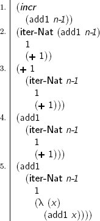

In other words,

(*incr*

(add1 *n-1*))

is the same Nat as

(add1

(**incr** n-1))

because (**incr** n-1) is the same Nat as

(**iter-Nat** *n-1*

1

(λ (*x*)

(add1 *x*))).

This is the observation.

<sup>69</sup>

Okay, so the type of *step-incr=add1* can also be written this way. There is a gray box around the part that is different from the version in frame 63.

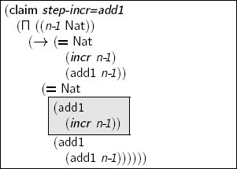

The box is now solid because it is easy to see why this type makes sense. If two Nats are equal, then one greater than both of them are also equal.

<sup>70</sup>

Okay. But how can it be made true with a proof?

**Observation about *incr***

**No matter which** Nat *n* **is,**

**(*incr* (**add1 *n***))**

**is the same** Nat **as**

**(**add1 **(****incr** n**))**.

Here’s the start of a definition of *step-incr=add1*.

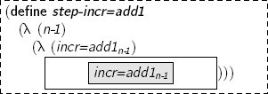

<sup>71</sup>

The almost-proof for *n-1* is an

(**=** Nat

(**incr** n-1)

(add1 *n-1*)).

What can be used in the white box to turn an almost-proof into a proof of

(**=** Nat

(add1

(**incr** n-1))

(add1

(add1 *n-1*)))?

**cong**† is an eliminator for **=** that is useful here.

_______________

†Short for “congruence.”

<sup>72</sup>

What is a **cong**-expression?

First things first. It’s time to sit back and have a

(*sandwich* 'submarine).

<sup>73</sup>

Another sandwich?

This is a bit too much to eat.

Returning to the problem at hand,

(**cong** *target f*)

is used to transform both expressions that *target* equates using *f*.

If *f* is an

(→ *X*

*Y*)

and *target* is an

(**=** *X from to*),

then

(**cong** *target f*)

is an

(**=** *Y* (*f from*) (*f to*)).

<sup>74</sup>

Is there another way to look at **cong**?

This diagram shows how **cong** is used.

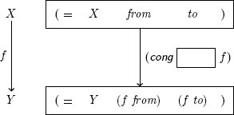

<sup>75</sup>

How can **cong** be used to complete the definition of *step-incr=add1*?

**The Law of cong**

**If** *f* **is an**

**(**→ *X*

*Y***)**

**and** *target* **is an (=** *X from to***)**,

**then (cong** *target f***) is an (=** *Y* **(***f from***) (***f to***))**.

In this case, *X* is Nat, *Y* is Nat, and *target* is *incr=add1<sub>n-1</sub>*.

What are *from* and *to*?

<sup>76</sup>

*incr=add1<sub>n-1</sub>*’s type is

(**=** Nat (**incr** n-1) (add1 *n-1*)),

so *from* is (**incr** n-1) and *to* is (add1 *n-1*).

What function *f* transforms

(**incr** n-1) into (add1 (**incr** n-1))

and

(add1 *n-1*) into (add1 (add1 *n-1*))?

<sup>77</sup>

In each case, an add1 is added to the top. How about using add1 for *f*?

add1 is a constructor, but it is not an expression when it is not used as the top of a Nat tucked under it.

An add1-expression must have an argument.

<sup>78</sup>

How about using *incr* for *f*?

While *incr* does indeed add one to its argument, it does not result in an add1 immediately when its argument is neutral.

<sup>79</sup>

How about using (**+** 1) for *f*?

An excellent choice. There is now an expression for the white box.

<sup>80</sup>

Okay.

(**define *step-incr=add1***

(λ (*n-1*)

(λ (*incr=add1<sub>n-1</sub>*)

(**cong** *incr=add1<sub>n-1</sub>* (**+** 1)))))

It is now possible to define *incr=add1*.

<sup>81</sup>

The motive, the base, and the step are now defined, so the previous definition of *incr=add1* in frame 59 is now solid.

(**define *incr=add1***

(λ (*n*)

(**ind-Nat** *n*

*mot-incr=add1*

*base-incr=add1*

*step-incr=add1*)))

It’s time for another sandwich:

(*sandwich* 'hero).

<sup>82</sup>

Another one!

Yes, another one.

Why is **ind-Nat** needed in the definition of *incr=add1*, but not in the definition of *+1=add1*?

<sup>83</sup>

Because the normal form of (**incr** n) is the neutral expression in frame 45, but based on the definition of **+**, the normal form of (**+** 1 *n*) is (add1 *n*).

Neutral expressions are those that cannot yet be evaluated, but replacing their variables with values could allow evaluation.

What is the type of

(*incr=add1* 2)?

<sup>84</sup>

The expression

(*incr=add1* 2)

is an

(**=** Nat (*incr* 2) (add1 2)).

In other words, it is an

(**=** Nat 3 3)

because (*incr* 2) is not neutral.

What is the normal form of

(*incr=add1* 2)?

<sup>85</sup>

Here’s the start of the chart.

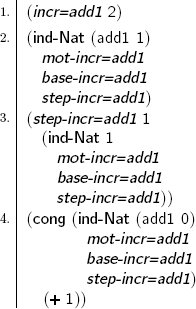

How is a **cong**-expression evaluated?

Like other eliminators, the first step in evaluating a **cong**-expression is to evaluate its target. If the target is neutral, the whole **cong**-expression is neutral, and thus there is no more evaluation.

<sup>86</sup>

What if the target is not neutral?

If the target is not neutral, then its value has same at the top because same is the only constructor for **=**-expressions.

The value of

(**cong** (same *x*) *f*)

is

(same (*f x*)).

<sup>87</sup>

Okay, the next step in finding the normal form is to find the value of **cong**’s target.

**ind-Nat**’s target has add1 at the top, so the next step is to use the step.

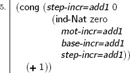

<sup>88</sup>

The next **ind-Nat**’s target is zero.

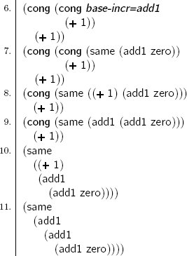

**The Commandment of cong**

**If** *x* **is an** *X***, and** *f* **is an**

**(**→ *X*

*Y***)**,

**then (cong (**same *x***)** *f***) is the same**

**(=** *Y* **(***f x***) (***f x***))**

**as**

**(**same **(***f x***)).**

| The interplay between judging sameness and stating equality is at the heart of working with dependent types. This first taste only scratches the surface. | <sup>89</sup> | But what about my stomach? There’s really only space for one sandwich. |
| --- | --- | --- |
| Today’s your lucky day! (**claim *sandwich*** (→ Atom Atom)) (**define *sandwich*** (λ (*which-sandwich*) **'**delicious)) | <sup>90</sup> | Oh, what a relief! There *is* just one sandwich: (same **'**delicious) is a proof that (*sandwich* 'hoagie), (*sandwich* 'grinder), (*sandwich* 'submarine), and (*sandwich* 'hero), are all equal. |

**Enjoy your sandwich, but if you’re full, wrap it up for later.**

**This page makes an excellent sandwich wrapper.**

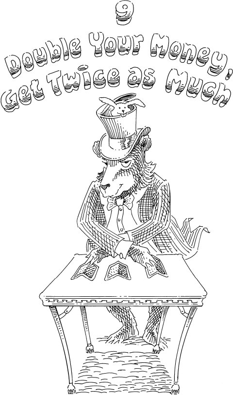

| In chapter 8, there is only one eliminator for **=**, called **cong**. But **cong** has one key limitation. | <sup>1</sup> | What is that? |
| --- | --- | --- |
| What is the type of a **cong**-expression? | <sup>2</sup> | By the Law of **cong**, if *target* is an (**=** *X from to*) and *f* is an (→ *X* *Y*), then (**cong** *target f*) is an (**=** *Y* (*f from*) (*f to*)). |
| That’s right. How is this different from eliminators such as **ind-Nat**? | <sup>3</sup> | An **ind-Nat**-expression can have *any* type—it all depends on the motive. But a **cong**-expression’s type always has **=** at the top. |
| **cong** is a special-purpose eliminator. But there is also a more general eliminator, called **replace**. | <sup>4</sup> | What does **replace** mean? |
| If two expressions are equal, then whatever is true for one is true for the other. We call this principle Leibniz’s Law.† _______________ †Leibniz’s Law is also used to refer to the principle that if … | <sup>5</sup> | What does this have to do with **replace**? |
| **replace** is more powerful than **cong** because any use of **cong** can be rewritten to a use of **replace**, just as any use of **which-Nat**, **iter-Nat**, or **rec-Nat** can be rewritten to a us… | <sup>6</sup> | How does **replace** differ from **cong**? |
| Like **cong**, **replace**’s target is an (**=** *X from to*). Unlike **cong**, however, **replace** has a motive and a base. | <sup>7</sup> | Is a **replace**-expression’s type determined by applying the motive to the target? |
| That is how the motive works in **ind-Nat**, but not in **replace**. In **replace**, the motive explains *what* is true for both expressions in Leibniz’s Law. It is an (→ *X* *U*) because it explains … | <sup>8</sup> | What about the base? |
| The base is evidence that (*mot from*) is true. That is, the base’s type is (*mot from*). | <sup>9</sup> | What about the whole **replace**-expression? |
| The whole **replace**-expression is evidence that (*mot to*) is true. In other words, its type is (*mot to*). | <sup>10</sup> | So **replace** replaces *from* with *to*. |
| Take a look at *step-incr=add1* in frame 8:80 on page 191. | <sup>11</sup> | Okay. It is defined using **cong**. |

**The Law of replace**

**If** *target* **is an**

**(****=** *X from to***)**,

*mot* **is an**

**(**→ *X*

*U***)**,

**and** *base* **is a**

**(***mot from***)**

**then**

**(replace** *target*

*mot*

*base***)**

**is a**

**(***mot to***)**.

That’s right.

But it could also be defined using **replace**.

What is the **claim** again?

<sup>12</sup>

Using the observation about *incr* in frame 8:68, the add1 is already on the outside of the *incr* as if it were ready for **cong**.

(**claim *step-incr=add1***

(Π ((*n-1* Nat))

(→ (**=** Nat

(**incr** n-1)

(add1 *n-1*))

(**=** Nat

(add1

(**incr** n-1))

(add1

(add1 *n-1*))))))

Here is the start of a definition using **replace**.

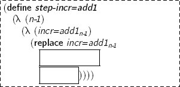

The target is *incr=add1<sub>n-1</sub>*, which is the only available proof of equality here.

<sup>13</sup>

The target, *incr=add1<sub>n-1</sub>*, is an

(**=** Nat

(**incr** n-1)

(add1 *n-1*)).

The whole **replace**-expression should be an

(**=** Nat

(add1

(**incr** n-1))

(add1

(add1 *n-1*))).

To find the motive, examine the **replace**-expression’s type.

Look for the TO of the target’s type.

<sup>14</sup>

The TO is (add1 *n-1*), which is certainly in the **replace**-expression’s type.

The motive is used to find the types of both the base and the whole **replace**-expression. The base’s type is found by placing the target’s type’s FROM in the gray box, while the entire expression’s type is found by placing the target’s type’s TO in the gray box.

<sup>15</sup>

An expression that is missing a piece can be written as a λ-expression.

To find the motive, abstract over the TO of the target’s type with a λ.

<sup>16</sup>

That gives this expression:

(λ (*k*)

(**=** Nat

(add1

(**incr** n-1))

(add1

*k*))).

But if **replace** replaces the FROM with the TO, why should we abstract over the TO, rather than the FROM?

The base’s type is found by applying the motive to the FROM of the target’s type. So, in this case, it is

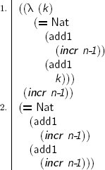

<sup>17</sup>

Applying the motive to an argument is like filling in the gray box.

Now that we know the base’s type, what is the base?

<sup>18</sup>

The base is

(same

(add1

(**incr** n-1))),

and leads to

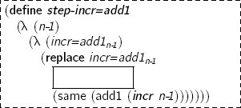

Now define the motive.

<sup>19</sup>

The motive takes *n-1* as an argument, just as *step*-∗ takes *j* as an argument.

(**claim *mot-step-incr=add1***

(→ Nat Nat

*U*))

(**define *mot-step-incr=add1***

(λ (*n-1 k*)

(**=** Nat

(add1

(**incr** n-1))

(add1

*k*))))

Finally, complete the definition from frame 17.

<sup>20</sup>

Because **step-incr=add1** is already defined in chapter 8, this remains in a dashed box.

(**define *step-incr=add1***

(λ (*n-1*)

(λ (*incr=add1<sub>n-1</sub>*)

(**replace** *incr=add1<sub>n-1</sub>*

(**mot-step-incr=add1** n-1)

(same (add1 (**incr** n-1)))))))

Yes, only one definition for each claim.

Now, define **double** to be a function that replaces each add1 in a Nat with two add1s.

(**claim *double***

(→ Nat

Nat))

<sup>21</sup>

This is a job for **iter-Nat**. The step is (**+** 2) because the normal form of (**+** 2) is

(λ (*j*)

(add1

(add1 *j*))).

(**define *double***

(λ (*n*)

(**iter-Nat** *n*

0

(**+** 2))))

(**double** n) is twice as big as *n*. What is another function that finds the same answer? Call it **twice**.

(**claim *twice***

(→ Nat

Nat))

<sup>22</sup>

How about this?

(**define *twice***

(λ (*n*)

(**+** *n n*)))

It happens to be the case that,

“For every Nat *n*, (**twice** *n*) equals (**double** *n*).”

How can this statement be written as a type?

<sup>23</sup>

Because this statement is likely to get a proof, it gets a name.

(**claim *twice=double***

(Π ((*n* Nat))

(**=** Nat (**twice** n) (**double** n))))

Very perceptive.

Why is this claim true?

<sup>24</sup>

Every Nat value is either zero or has add1 at the top. Both (**twice** zero) and (**double** zero) are zero.

What about add1?

<sup>25</sup>

For add1,

(**twice** (add1 *n-1*))

is the same Nat as

(**+** (add1 *n-1*) (add1 *n-1*)),

but

(**double** (add1 *n-1*))

is the same Nat as

(add1 (add1 (**double** n-1))).

Is

(**+** (add1 *n-1*) (add1 *n-1*))

the same Nat as

(add1 (add1 (**+** *n-1 n-1*)))?

<sup>26</sup>

No, it isn’t.

But surely they must be equal.

That’s right.

To prove **twice=double**, an extra proof is needed. While an add1 around **+**’s *first* argument can be moved above **+**, an add1 around **+**’s *second* argument cannot be—at least not without a proof.

<sup>27</sup>

Right, because only the first argument is the target of **iter-Nat** in **+**’s definition.

Even though

(**+** *n* (add1 *j*))

is not the same Nat as

(add1 (**+** *n j*)),

they are equal Nats.

<sup>28</sup>

They are not the same, but one can be **replace**d with the other.

The statement to be proved is **add1+=+add1**.

(**claim *add1+=+add1***

(Π ((*n* Nat)

(*j* Nat))

(**=** Nat

(add1 (**+** *n j*))

(**+** *n* (add1 *j*)))))

<sup>29</sup>

This looks like a job for **ind-Nat**.

(**define *add1+=+add1***

(λ (*n j*)

(**ind-Nat** *n*

(**mot-add1+=+add1** j)

(same (add1 *j*))

(**step-add1+=+add1** j))))

The motive and the step both need *j*, just like *step*-∗. The base is

(same (add1 *j*)).

Why is the base

(same (add1 *j*))?

<sup>30</sup>

Because

(add1 (**+** zero *j*))

is the same Nat as

(add1 *j*)

and

(**+** zero (add1 *j*))

is also the same Nat as

(add1 *j*).

What is **mot-add1+=+add1**?

<sup>31</sup>

It is the type of the **ind-Nat**-expression, abstracted over the target. In other words, every occurrence of *n* in the claim **add1+=+add1** becomes *k*.

(**claim *mot-add1+=+add1***

(→ Nat Nat

*U*))

(**define *mot-add1+=+add1***

(λ (*j k*)

(**=** Nat

(add1 (**+** *k j*))

(**+** *k* (add1 *j*)))))

Here is **step-add1+=+add1**’s type.

(**claim *step-add1+=+add1***

(Π ((*j* Nat)

(*n-1* Nat))

(→ (**mot-add1+=+add1** j

*n-1*)

(**mot-add1+=+add1** j

(add1 *n-1*)))))

What is a more explicit way to write

(**mot-add1+=+add1** j

(add1 *n-1*))?

<sup>32</sup>

Applying **mot-add1+=+add1** gives

(**=** Nat

(add1 (**+** (add1 *n-1*) *j*))

(**+** (add1 *n-1*) (add1 *j*))).

That type and

(**=** Nat

(add1 (add1 (**+** *n-1 j*)))

(add1 (**+** *n-1* (add1 *j*))))

are the same type. This is because the first argument to **+** is the target of **iter-Nat**.

Now define **step-add1+=+add1**.

<sup>33</sup>

It uses **cong**.

(**define *step-add1+=+add1***

(λ (*j n-1*)

(λ (*add1+=+add1<sub>n-1</sub>*)

(**cong** *add1+=+add1<sub>n-1</sub>*

(**+** 1)))))

What role do **cong** and (**+** 1) play in the definition?

<sup>34</sup>

*add1+=+add1<sub>n-1</sub>* is an

(**=** Nat

(add1 (**+** *n-1 j*))

(**+** *n-1* (add1 *j*))),

so using (**+** 1) with **cong** wraps both the FROM and the TO with add1, which gives the type from frame 32.

The definition of **add1+=+add1** now deserves a solid box because every name that it mentions is now defined.

<sup>35</sup>

Here it is.

(**define *add1+=+add1***

(λ (*n j*)

(**ind-Nat** *n*

(**mot-add1+=+add1** j)

(same (add1 *j*))

(**step-add1+=+add1** j))))

Because of frame 35, it is *true* that, for all Nats *n* and *j*,

(add1 (**+** *n j*))

equals

(**+** *n* (add1 *j*)).

<sup>36</sup>

Right.

This also means that

(add1 (**+** *n-1 n-1*))

equals

(**+** *n-1* (add1 *n-1*))

because *n* and *j* can both be *n-1*.

What expression has the type

(**=** Nat

(add1 (**+** *n-1 n-1*))

(**+** *n-1* (add1 *n-1*)))?

<sup>37</sup>

The expression

(**add1+=+add1** n-1 n-1)

is an

(**=** Nat

(add1 (**+** *n-1 n-1*))

(**+** *n-1* (add1 *n-1*))).

Now, use the fact that

(**+** *n-1* (add1 *n-1*))

equals

(add1 (**+** *n-1 n-1*))

to prove **twice=double**.

<sup>38</sup>

The statement in frame 24 suggests an **ind-Nat**-expression.

(**define *twice=double***

(λ (*n*)

(**ind-Nat** *n*

**mot-twice=double**

(same zero)

**step-twice=double**)))

What is **mot-twice=double**?

<sup>39</sup>

It follows the usual approach of abstracting over the target.

(**claim *mot-twice=double***

(→ Nat

*U*))

(**define *mot-twice=double***

(λ (*k*)

(**=** Nat

(**twice** k)

(**double** k))))

What about **step-twice=double**?

<sup>40</sup>

**step-twice=double**’s type is built the same way as for every other step.

(**claim *step-twice=double***

(Π ((*n-1* Nat))

(→ (**mot-twice=double** n-1)

(**mot-twice=double** (add1 *n-1*)))))

Here’s the beginning of the definition.

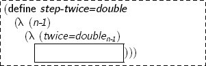

What is *twice=double<sub>n-1</sub>*’s type?

<sup>41</sup>

*twice=double<sub>n-1</sub>* is an

(**=** Nat

(**twice** n-1)

(**double** n-1)).

The box’s type is

(**=** Nat

(**twice** (add1 *n-1*))

(**double** (add1 *n-1*))),

and that type and

(**=** Nat

(add1

(**+** *n-1* (add1 *n-1*)))

(add1

(add1 (**double** n-1))))

are the same type.

<sup>42</sup>

Frame 25 explains why

(**double** (add1 *n-1*))

is the same Nat as

(add1

(add1 (**double** n-1))).

Why is

(**twice** (add1 *n-1*))

the same Nat as

(add1

(**+** *n-1* (add1 *n-1*)))?

An observation about **+** comes in handy. No matter which Nats *j* and *k* are,

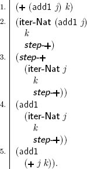

<sup>43</sup>

This is very much like the observation about **incr** on page 189.

**Observation about +**

**No matter which** Nat**s** *j* **and** *k* **are,**

**(+ (**add1 *j***)** *k***)**

**is the same** Nat **as**

**(**add1

**(+** *j k***))**.

Can **cong** do the job?

<sup>44</sup>

The expression

(**cong** *twice=double<sub>n-1</sub>*

(**+** 2))

is an

(**=** Nat

(add1

(add1 (**+** *n-1 n-1*)))

(add1

(add1 (**double** n-1)))),

which is not the same type.

It is not the same type, but it is *nearly* the same type.

<sup>45</sup>

Replacing

(add1 (**+** *n-1 n-1*))

with

(**+** *n-1* (add1 *n-1*)),

in the type would do the trick.

Because

(add1 (**+** *n-1 n-1*))

equals

(**+** *n-1* (add1 *n-1*)),

**replace** can move the add1 from the second argument of **+** to the outside.

<sup>46</sup>

Right, because **replace** is used when the type of something *nearly* fits, and the part that doesn’t is equal to something that would make it fit.

In this case, which part of the type of

(**cong** *twice=double<sub>n-1</sub>*

(**+** 2))

fits?

<sup>47</sup>

Everything but this gray box fits just fine.

Now define the motive.

**mot-step-twice=double** needs an extra argument, just like *step*-∗.

(**claim *mot-step-twice=double***

(→ Nat Nat

*U*))

<sup>48</sup>

The empty box becomes a λ-expression’s variable.

(**define *mot-step-twice=double***

(λ (*n-1 k*)

(**=** Nat

(add1

*k*)

(add1

(add1 (**double** n-1))))))

What is the target of the **replace**-expression?

<sup>49</sup>

The expression

(add1 (**+** *n-1 n-1*))

should be replaced by

(**+** *n-1* (add1 *n-1*)),

so the target should be

(**add1+=+add1** n-1 n-1).

Here is the definition so far.

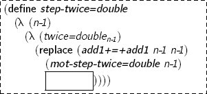

<sup>50</sup>

The base is the expression whose type is nearly right, which is

(**cong** *twice=double<sub>n-1</sub>*

(**+** 2)).

What is the complete definition of **step-twice=double**?

<sup>51</sup>

The function that is one of the arguments to **cong** is (**+** 2).

(**define *step-twice=double***

(λ (*n-1*)

(λ (*twice=double<sub>n-1</sub>*)

(**replace** (**add1+=+add1** n-1 n-1)

(**mot-step-twice=double** n-1)

(**cong** *twice=double<sub>n-1</sub>*

(**+** 2))))))

And, finally, **twice=double** deserves a solid box.

<sup>52</sup>

So far, the type of each

**replace**-expression has **=** at the top.

(**define *twice=double***

(λ (*n*)

(**ind-Nat** *n*

**mot-twice=double**

(same zero)

**step-twice=double**)))

Good point. **replace** is useful because by writing an appropriate motive, it can have any type.

Find two proofs that,

“(**twice** 17) equals (**double** 17).”

(**claim *twice=double-of-17***

(**=** Nat (**twice** 17) (**double** 17)))

(**claim *twice=double-of-17-again***

(**=** Nat (**twice** 17) (**double** 17)))

<sup>53</sup>

If a statement is true for every Nat, then it is true for 17. One way to prove it is to apply **twice=double** to 17.

(**define *twice=double-of-17***

(**twice=double** 17))

This is similar to **twin-Atom** in frame 4:54.

What’s the other proof?

<sup>54</sup>

(**twice** 17) is already the same Nat as (**double** 17), so same can also be used.

(**define *twice=double-of-17-again***

(same 34))

In fact, (same 34) is even the value of

**twice=double-of-17**.

Define a function called **twice-Vec** that duplicates each entry in a Vec. For example, the normal form of

(**twice-Vec** Atom 3

(vec:: **'**chocolate-chip

(vec:: **'**oatmeal-raisin

(vec:: **'**vanilla-wafer

vecnil))))

is

(vec:: **'**chocolate-chip

(vec:: **'**chocolate-chip

(vec:: **'**oatmeal-raisin

(vec:: **'**oatmeal-raisin

(vec:: **'**vanilla-wafer

(vec:: **'**vanilla-wafer

vecnil)))))).

<sup>55</sup>

What should the type be?

As the name suggests, the function makes a Vec with **twice** as many entries.

(**claim *twice-Vec***

(Π ((*E U*)

(*ℓ* Nat))

(→ (Vec *E* *ℓ*)

(Vec *E* (**twice** *ℓ*)))))

<sup>56</sup>

This sounds difficult.

Why is that?

<sup>57</sup>

Because the type depends on a Nat, the function suggests using **ind-Nat** with a step that uses vec:: twice.

To use vec::, the desired length must have add1 on top. The length of this Vec, however, will have only one add1 on top.

Why is there only a single add1 at the top of the length?

<sup>58</sup>

Based on observation about **+** from page 210,

(**twice** (add1 *n-1*))

is the same

Nat

as

(add1 (**+** *n-1* (add1 *n-1*))).

Here’s a more direct way to state the problem.

(**claim *double-Vec***

(Π ((*E U*)

(*ℓ* Nat))

(→ (Vec *E* *ℓ*)

(Vec *E* (**double** *ℓ*)))))

<sup>59</sup>

That is easier to define with **ind-Nat**. Here’s the base.

(**claim *base-double-Vec***

(Π ((*E U*))

(→ (Vec *E* zero)

(Vec *E* (**double** zero)))))

(**define *base-double-Vec***

(λ (*E*)

(λ (*es*)

vecnil)))

That’s right—doubling an empty Vec is still empty. What about the motive?

(**claim *mot-double-Vec***

(→ *U* Nat

*U*))

<sup>60</sup>

It can be found by abstracting over zero in the base’s type.

(**define *mot-double-Vec***

(λ (*E k*)

(→ (Vec *E k*)

(Vec *E* (**double** k)))))

How about the step?

(**claim *step-double-Vec***

(Π ((*E U*)

(*ℓ**-1* Nat))

(→ (→ (Vec *E* *ℓ**-1*)

(Vec *E* (**double** *ℓ**-1*)))

(→ (Vec *E* (add1 *ℓ**-1*))

(Vec *E*

(**double** (add1 *ℓ**-1*)))))))

<sup>61</sup>

The step transforms a doubler for a Vec with *ℓ**-1* entries into a doubler for a Vec with (add1 *ℓ**-1*) entries. And

(**double**

(add1 *ℓ**-1*))

is the same Nat as

(add1

(add1

(**double** ℓ-1))),

so the two uses of vec:: are expected.

(**define *step-double-Vec***

(λ (*E ℓ-1*)

(λ (*double-Vec<sub>ℓ-1</sub>*)

(λ (*es*)

(vec:: (**head** *es*)

(vec:: (**head** *es*)

(*double-Vec*<sub>*ℓ-1*</sub>

(**tail** *es*))))))))

What is the definition of **double-Vec**?

<sup>62</sup>

All of its parts are defined, so it deserves a solid box.

(**define *double-Vec***

(λ (*E ℓ*)

(**ind-Nat** *ℓ*

(**mot-double-Vec** E)

(**base-double-Vec** E)

(**step-double-Vec** E))))

Even though it is true that (**double** n) equals (**twice** n) for all Nats *n*, it is not equally easy to define dependent functions that use them. **double-Vec** is easy, while **twice-Vec** is not.

<sup>63</sup>

That’s right.

The proof that (**double** n) equals (**twice** n) for all Nats *n* can be used to define **twice-Vec** using **double-Vec**.

<sup>64</sup>

That certainly saves a lot of effort.

**Solve Easy Problems First**

**If two functions produce equal results, then use the easier one when defining a dependent function, and then use replace to give it the desired type.**

The type of

(**double-Vec** E ℓ es)

is

(Vec *E* (**double** ℓ)).

The (**double** ℓ) needs to become (**twice** ℓ).

What is the target?

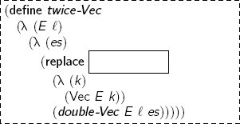

<sup>65</sup>

What about (**twice=double** ℓ)?

That’s very close, but

(**twice=double** ℓ)

is an

(**=** Nat (**twice** ℓ) (**double** ℓ)),

which has the TO and the FROM in the wrong order.

<sup>66</sup>

Does this mean that we need to prove **double=twice** now?

Luckily, that’s not necessary. Another special eliminator for **=**, called **symm**†, fixes this problem.

If *target* is an

(**=** *X from to*),

then

(**symm** *target*)

is an

(**=** *X to from*).

_______________

†Short for “symmetry.”

<sup>67</sup>

Okay, it’s possible to define **twice-Vec**.

(**define *twice-Vec***

(λ (*E ℓ*)

(λ (*es*)

(**replace** (**symm**

(**twice=double** ℓ))

(λ (*k*)

(Vec *E k*))

(**double-Vec** E ℓ es)))))

That’s right.

<sup>68</sup>

Whew!

**The Law of symm**

**If** *e* **is an (****=** *X from to***), then (symm** *e***) is an (****=** *X to from***).**

**The Commandment of symm**

**If** *x* **is an** *X***, then**

**(symm (**same *x***))**

**is the same**

**(****=** *X x x***)**

**as**

**(**same *x***)**.

**Now go eat all the cookies you can find,**

**and dust off your lists.**

[figure not shown]

Before we get started, here are three more expectations. Have you *…*

1. figured out why we need induction,
2. understood **ind-Nat**, and
3. built a function with induction?

<sup>1</sup>

More expectations! Here are all the expectations from frame 5:2, together with these three new expectations. The expectations are to have

- cooked ratatouille,
- eaten two pieces of cherry pie,
- tried to clean up with a non-napkin,
- understood **rec-Nat**, and
- slept until well-rested; as well as
1. figured out why we need induction,
2. understood **ind-Nat**, and
3. built a function with induction.

It seems that these lists are mismatched. The lists from chapter 5 don’t have obvious lengths, while these lists do.

(**claim *more-expectations***

(Vec Atom 3))

(**define *more-expectations***

(vec:: **'**need-induction

(vec:: **'**understood-induction

(vec:: **'**built-function vecnil))))

<sup>2</sup>

But **append** can’t mix a List and a Vec.

No, it can’t. That is a job for **vec-append**, which is not yet defined. To use **vec-append** on a List, we must transform it into a Vec.

<sup>3</sup>

But to build a Vec, don’t we need a number of entries?

There is another possibility.

Previous definitions that used Vec accepted the number of entries as arguments. But with a new twist on an old type, it is possible to build the Vec and its length together.

<sup>4</sup>

What is that new twist?

What does it mean for a value to be a

(Pair *A D*)?

<sup>5</sup>

A value is a (Pair *A D*) if

1. it has cons at the top,
2. its **car** is an *A*, and
3. its **cdr** is a *D*.

If

(cons *a d*)

is a

(Σ † ((*x A*))

*D*),

then *a*’s type is *A* and *d*’s type is found by consistently replacing every *x* in *D* with *a*.

_______________

†Σ is pronounced “sigma;” also written Sigma.

<sup>6</sup>

When is

(Σ ((*x A*))

*D*)

a type?

The expression

(Σ ((*x A*))

*D*)

is a type when

1. *A* is a type, and
2. *D* is a type if *x* is an *A*.†

Is

(Σ ((*bread* Atom))

(**=** Atom *bread* **'**bagel))

a type?

_______________

†Another way to say this is “*D* is a family of types over *A*.” This terminology is also used for the body of a Π-expression.

<sup>7</sup>

Yes, because Atom is a type, and

(**=** Atom *bread* **'**bagel)

is a type when *bread* is an Atom.

What expression has the type

(Σ ((*bread* Atom))

(**=** Atom *bread* **'**bagel))?

<sup>8</sup>

How about (cons **'**bagel (same **'**bagel))?

Indeed.

Is

(Σ ((*A U*))

*A*)

a type?

<sup>9</sup>

*U* is a type, and *A* is certainly a type when *A* is a *U*.

**The Law of** Σ

**The expression**

**(Σ ((***x A***))**

*D***)**

**is a type when** *A* **is a type, and** *D* **is a type if** *x* **is an** *A***.**

**The Commandment of** cons

**If** *p* **is a**

**(Σ ((***x A***))**

*D***)**,

**then** *p* **is the same as**

**(**cons **(car** *p***) (cdr** *p***))**.

Name three expressions that have that type.

<sup>10</sup>

Nat is a *U* and 4 is a Nat, so

(cons Nat 4)

is a

(Σ ((*A U*))

*A*).

Two more expressions with that type are

(cons Atom **'**porridge),

and

(cons (→ Nat

Nat)

(**+** 7)).

Is

(cons **'**toast

(same (:: **'**toast nil)))

a

(Σ ((*food* Atom))

(**=** (List Atom)

(:: *food* nil)

(:: **'**toast nil)))?

<sup>11</sup>

Yes, it is, because consistently replacing *food* with **'**toast in

(**=** (List Atom)

(:: *food* nil)

(:: **'**toast nil))

is

(**=** (List Atom)

(:: **'**toast nil)

(:: **'**toast nil)),

so (same (:: **'**toast nil)) is acceptable.

What is the relationship between Σ and Pair?

(Pair *A D*) is a short way of writing

(Σ ((*x A*))

*D*)

where *x* is not used in *D*.

<sup>12</sup>

This is similar to how some Π-expressions can be written as →-expressions, from frame 6:40.

How can Σ combine a number of entries with a Vec?

Like this:

(Σ ((*ℓ* Nat))

(Vec Atom *ℓ*)).

<sup>13</sup>

What values have that type?

Here are seventeen **'**peas:

(cons 17 (**peas** 17)).

Now give another.

<sup>14</sup>

How about a nice breakfast?

(cons 2

(vec:: **'**toast-and-jam

(vec:: **'**tea vecnil)))

It’s good to start the day off right.

Types built with →, Π, and **=** can be read as statements, and expressions of those types are proofs. Similarly, types built with Pair and Σ can be read as statements.

<sup>15</sup>

How can (Pair *A D*) be read as a statement?

A (Pair *A D*) consists of both evidence for *A* and evidence for *D*, with cons at the top. This means that (Pair *A D*) can be read

“*A* and *D*”

because to give evidence for an “and” is to give evidence for both parts.

How can

(Pair (**=** Nat 2 3)

(**=** Atom **'**apple **'**apple))

be read as a statement?

<sup>16</sup>

It is the statement

“2 equals 3 and **'**apple equals **'**apple.”

There is no evidence for this statement, because there is no evidence for

“2 equals 3.”

and thus nothing to put in the **car**.

Evidence for

(Σ ((*x A*))

*D*)

is a pair whose **car** is an *A* and whose **cdr** is evidence for the statement found by consistently replacing each *x* in *D* with the **car**.

<sup>17</sup>

What does that mean for Σ’s reading as a statement?

A Σ-expression can be read as

“there exists.”

For example,

(Σ ((*es* (List Atom)))

(**=** (List Atom)

*es*

(**reverse** Atom *es*)))

can be read as

“There exists a list of atoms that is equal to itself reversed.”

<sup>18</sup>

Is that statement even true?

Here’s a proof: (cons nil (same nil)).

<sup>19</sup>

Of course, because reversing the empty list is the empty list.

Are there any other proofs?

<sup>20</sup>

Yes, many lists are equal forwards and backwards.† Here is another proof:

(cons (:: **'**bialy

(:: **'**schmear

(:: **'**bialy nil)))

(same (:: **'**bialy

(:: **'**schmear

(:: **'**bialy nil))))).

_______________

†These lists are called *palindromes*.

How can this expression be read as a statement?

(Σ ((*es* (List Atom)))

(**=** (List Atom)

(**snoc** Atom *es* **'**grape)

(:: **'**grape *es*))).

<sup>21</sup>

“There exists a list of atoms such that adding **'**grape to the back or the front does the same thing.”

Now prove it.

<sup>22</sup>

Adding **'**grape to the back or front of nil does the same thing:

(cons nil

(same (:: **'**grape nil))).

That’s a proof.

Is there any other proof?

<sup>23</sup>

Any list of only **'**grapes works.

Here’s another one:

(cons (:: **'**grape

(:: **'**grape

(:: **'**grape nil)))

(same (:: **'**grape

(:: **'**grape

(:: **'**grape

(:: **'**grape nil)))))).

There’s no way to tell one **'**grape from another, so front or back does not matter.

Great job.

What is the type of a function that transforms a List into a Vec?

<sup>24</sup>

Won’t **list→vec**’s type need to use Σ?

(**claim *list→vec***

(Π ((*E U*))

(→ (List *E*)

(Σ ((*ℓ* Nat))

(Vec *E* *ℓ*)))))

That’s correct, at least for now.

Here is part of the definition. What goes in the box?

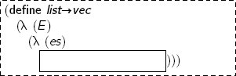

<sup>25</sup>

The expression in the box must check whether *es* is nil or has :: at the top. **rec-List** does that, and the target is *es*.

That’s correct.

What is the base?

<sup>26</sup>

The base is the value when *es* is nil. That should clearly be vecnil, and vecnil has 0 entries.

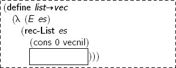

Why is

(cons 0 vecnil)

a

(Σ ((*ℓ* Nat))

(Vec *E* *ℓ*))?

<sup>27</sup>

Because the **car** is a Nat, specifically 0, and the **cdr** is a (Vec *E* 0).

**step-list→vec** adds one entry to a

(Σ ((*ℓ* Nat))

(Vec *E* *ℓ*)).

What is the longer Vec’s type?

<sup>28</sup>

How about

(Σ ((*ℓ* Nat))

(Vec *E* (add1 *ℓ*))),

because the Vec is one entry longer?

A better type is

(Σ ((*ℓ* Nat))

(Vec *E* *ℓ*))

because the point of using Σ is to have a pair whose **car** is the entire length of the **cdr**. Making the **car** larger does not change the type.

Define the step.

<sup>29</sup>

The type follows the usual approach for **rec-List**.

(**claim *step-list→vec***

(Π ((*E U*))

(→ *E* (List *E*) (Σ ((*ℓ* Nat))

(Vec *E* *ℓ*))

(Σ ((*ℓ* Nat))

(Vec *E* *ℓ*)))))

To define **step-list→vec**, an eliminator for Σ is needed. Do **car** and **cdr** eliminate Σ, too?

Yes. If *p* is a

(Σ ((*x A*))

*D*),

then (**car** *p*) is an *A*.

<sup>30</sup>

That is just like (Pair *A D*).

But **cdr** is slightly different.

If *p* is a

(Σ ((*x A*))

*D*),

then (**cdr** *p*)’s type is *D* where every *x* has been consistently replaced with (**car** *p*).

<sup>31</sup>

If there is no *x* in *D*, then isn’t this the way Pair from chapter 1 works?

Indeed.

If *p* is a

(Σ ((*ℓ* Nat))

(Vec Atom *ℓ*)),

then what is (**car** *p*)’s type?

<sup>32</sup>

(**car** *p*) is a Nat.

If *p* is a

(Σ ((*ℓ* Nat))

(Vec Atom *ℓ*)),

then what is (**cdr** *p*)’s type?

<sup>33</sup>

(**cdr** *p*) is a (Vec Atom (**car** *p*)).

So Σ is another way to construct a dependent type.

Here is **step-list→vec**.

(**define *step-list→vec***

(λ (*E*)

(λ (*e es list→vec<sub>es</sub>*)

(cons (add1 (**car** *list→vec<sub>es</sub>*))

(vec:: *e* (**cdr** *list→vec<sub>es</sub>*))))))

Please explain it.

<sup>34</sup>

Here goes.

1. The body of the inner λ-expression has cons at the top because it must construct a Σ.
2. The **car** of the inner λ-expression’s body is

   (add1 (**car** *list→vec<sub>es</sub>*))

   because **step-list→vec** builds a Vec with one more entry than

   (**cdr** *list→vec<sub>es</sub>*).
3. The **cdr** of the inner λ-expression’s body has one more entry than the **cdr** of *list→vec<sub>es</sub>*, namely *e*. vec:: adds this new entry.

Now, give a complete definition of **list→vec**.

<sup>35</sup>

The box is filled with (**step-list→vec** E).

(**define *list→vec***

(λ (*E*)

(λ (*es*)

(**rec-List** *es*

(cons 0 vecnil)

(**step-list→vec** E)))))

How might this version of **list→vec** be summarized?

<sup>36</sup>

This **list→vec** converts a list into a pair where the **car** is the length of the list and the **cdr** is a Vec with that many entries.

For nil, the length is 0 and the Vec is vecnil. For ::, the length is one greater than the length of the converted rest of the list, and vec:: adds the same entry that :: added.

What is the value of

(**list→vec** Atom

(:: **'**beans

(:: **'**tomato nil)))?

<sup>37</sup>

Let’s see.

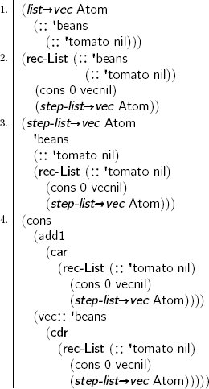

What is the normal form? The “same-as” chart can be skipped.

<sup>38</sup>

The normal form is

(cons 2

(vec:: **'**beans

(vec:: **'**tomato vecnil))).

The definition of **list→vec** is in a dashed box.

Why?

<sup>39</sup>

That means that there is something the matter with it?

The type given for **list→vec** is not specific enough.

The whole point of Vec is to keep track of how many entries are in a list, but wrapping it in a Σ hides this information. In chapter 7, specific types were used to make functions total. But specific types can also rule out foolish definitions.

<sup>40</sup>

But this definition is correct, isn’t it? The starting expression

(:: **'**beans

(:: **'**tomato nil))

appears to be the expected normal form. Here it is with its length:

(cons 2

(vec:: **'**beans

(vec:: **'**tomato vecnil))).

**Use a Specific Type for Correctness**

**Specific types can rule out foolish definitions.**

Here is a foolish definition that the type of **list→vec** permits.

(**define *list→vec***

(λ (*E*)

(λ (*es*)

(cons 0 vecnil))))

<sup>41</sup>

Applying this **list→vec** to any type and any list yields (cons 0 vecnil).

That’s correct.

What might another incorrect, yet still type-correct, definition be?

<sup>42</sup>

**list→vec** could be a function that always produces a Vec with 52 entries.

Almost.

Can it produce 52 entries, each of which has type *E*, when *es* is nil?

<sup>43</sup>

We don’t know ahead of time which *U* is to be the *E* that is the argument to the λ-expression. So there is no way to find an entry with that type when *es* is nil.

**list→vec** could be a function that produces a Vec with 52 entries when *es* has :: at the top, or 0 entries when *es* is nil, right?

Yes, it could.

Writing vec:: 52 times would be tiring, though.

<sup>44</sup>

A definition similar to **peas** would help with that.

Good idea. Call it **replicate**. Just as with **peas**, the definition of **replicate** requires the use of **ind-Nat**.

Why?

<sup>45</sup>

The definition of **replicate** requires the use of **ind-Nat** because, in **replicate**’s type, the Nat *ℓ* is the target.

(**claim *replicate***

(Π ((*E U*)

(*ℓ* Nat))

(→ *E*

(Vec *E* *ℓ*))))

The body of the Π-expression *depends on ℓ*, and **ind-Nat** is used when a type depends on the target.

Even though it is now time for breakfast, chapter 7 was not spent in vain!

What is the base?

<sup>46</sup>

The base is a

(Vec *E* 0),

so it must be

vecnil.

Here is **mot-replicate**’s type.

(**claim *mot-replicate***

(→ *U* Nat

*U*))

Now define **mot-replicate**.

<sup>47</sup>

The definition of **mot-replicate** follows a familiar approach, abstracting over zero as in frame 7:66.

(**define *mot-replicate***

(λ (*E k*)

(Vec *E k*)))

The next step is to define **step-replicate**.

<sup>48</sup>

At each step, **step-replicate** should add an entry to the list.

Where does that entry come from?

Just as *E* is an argument to **mot-replicate**, both *E* and *e* are arguments to **step-replicate**.

This is similar to the way *step*-∗ is applied to *j* in frame 3:66.

<sup>49</sup>

Here is **step-replicate**’s definition.

(**claim *step-replicate***

(Π ((*E U*)

(*e E*)

(*ℓ**-1* Nat))

(→ (**mot-replicate** E ℓ-1)

(**mot-replicate** E (add1 *ℓ**-1*)))))

(**define *step-replicate***

(λ (*E e ℓ-1*)

(λ (*step-replicate<sub>ℓ-1</sub>*)

(vec:: *e step-replicate<sub>ℓ-1</sub>*))))

Now define **replicate** using the motive, the base, and the step.

<sup>50</sup>

The components are all available.

(**define *replicate***

(λ (*E ℓ*)

(λ (*e*)

(**ind-Nat** *ℓ*

(**mot-replicate** E)

vecnil

(**step-replicate** E e)))))

In frame 49, **mot-replicate** is applied to two arguments, but here, it is applied to one. Also, **step-replicate** is applied to four arguments, but here, it is applied to only two.

Why?

<sup>51</sup>

Every motive for **ind-Nat** has type

(→ Nat

*U*).

Because of Currying, (**mot-replicate** E) has that type.

Similarly, every step for **ind-Nat** is applied to two arguments. Because of Currying, applying the first two arguments to the four-argument **step-replicate** produces the expected two-argument function.

**replicate** is intended to help write an alternative definition of **list→vec** that produces a Vec with 52 entries when *es* has :: at the top, or 0 entries when *es* is nil.

<sup>52</sup>

Here, cons in the definition of **copy-52-times** is the constructor of Σ, used to associate the length with the Vec.

(**claim *copy-52-times***

(Π ((*E U*))

(→ *E*

(List *E*)

(Σ ((*ℓ* Nat))

(Vec *E* *ℓ*))

(Σ ((*ℓ* Nat))

(Vec *E* *ℓ*)))))

(**define *copy-52-times***

(λ (*E*)

(λ (*e es copy-52-times<sub>es</sub>*)

(cons 52 (**replicate** E 52 *e*)))))

(**define *list→vec***

(λ (*E*)

(λ (*es*)

(**rec-List** *es*

(cons 0 vecnil)

(**copy-52-times** E)))))

The type can be made more specific by making clear the relationship between the List and the number of entries in the Vec.

What is that relationship?

<sup>53</sup>

The number of entries in the Vec is the length of the List.

Exactly. Here is a more specific type.

(**claim *list→vec***

(Π ((*E U*)

(*es* (List *E*)))

(Vec *E* (**length** E es))))

<sup>54</sup>

How can **list→vec** be defined?

Some of it should be predictable.

<sup>55</sup>

Yes, the type of **list→vec** predicts some of **list→vec**’s definition.

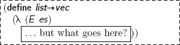

What is the type of the box?

<sup>56</sup>

The type of the box is the body of the Π-expression in the type of **list→vec**, which is

(Vec *E* (**length** E es)).

If *es* were a Nat, then **ind-Nat** would work. But *es* is a (List *E*).

Is there an **ind-List**?

Good thinking.

**ind-Nat** requires one more argument than **rec-Nat**, the motive.

<sup>57</sup>

Does **ind-List** also need a motive?

**ind-List** requires one more argument than **rec-List**, and this argument is also a motive:

(**ind-List** *target*

*mot*

*base*

*step*).

<sup>58</sup>

What is that expression’s type?

First, *target* is a (List *E*).

<sup>59</sup>

Of course.

Otherwise, **ind-List** would not be induction on List.

Just as in **ind-Nat**, *mot* explains the reason for doing induction. In other words, it explains the manner in which the type of the **ind-List**-expression depends on *target*.

What type should *mot* have?

<sup>60</sup>

*mot* finds a type when applied to a list, so it is an

(→ (List *E*)

*U*).

What type should *base* have?

<sup>61</sup>

*base* is a (*mot* nil) because nil plays the same role as zero.

The constructor :: plays a role similar to add1, except :: has two arguments: an entry and a list.

<sup>62</sup>

Does the step for **ind-List** have a type that is similar to the step for **ind-Nat**?

Just like the step for **ind-Nat** transforms an almost-answer for *n* into an answer for (add1 *n*), the step for **ind-List** takes an almost-answer for some list *es* and constructs an answer for (:: *e es*).

*step*’s type is

(Π ((*e E*)

(*es* (List *E*)))

(→ (*mot es*)

(*mot* (:: *e es*)))).

<sup>63</sup>

Here, adding an entry *e* to *es* with :: is like adding one with add1 in **ind-Nat**.

**The Law of ind-List**

**If** *target* **is a (**List *E***),**

*mot* **is an**

**(**→ **(**List *E***)**

*U***)**,

*base* **is a (***mot* nil**), and** *step* **is a**

**(Π ((***e E***)**

**(***es* **(**List *E***)))**

**(**→ **(***mot es***)**

**(***mot* **(**:: *e es***))))**

**then**

**(ind-List** *target*

*mot*

*base*

*step***)**

**is a (***mot target***).**

**The First Commandment of ind-List**

**The ind-List-expression**

**(****ind-List** nil

*mot*

*base*

*step***)**

**is the same (***mot* nil**) as** *base***.**

**The Second Commandment of ind-List**

**The ind-List-expression**

**(ind-List (**:: *e es***)**

*mot*

*base*

*step***)**

**is the same (***mot* **(**:: *e es***)) as**

**(***step e es*

**(ind-List** *es*

*mot*

*base*

*step***))**.

| Nat and List are closely related. Thus, an **ind-List**-expression’s type is (*mot target*). | <sup>64</sup> | As expected. |
| --- | --- | --- |
| The box in frame 55 should be filled by an **ind-List**-expression. | <sup>65</sup> | The target is *es*. (**define *list→vec*** (λ (*E es*) (**ind-List** *es* *mot-list→vec* *base-list→vec* *step-list→vec*))) |
| Could → have been used to write the Π-expression in the type of **list→vec** in frame 54? | <sup>66</sup> | No, because the type (Vec *E* (**length** E es)) depends on both *E* and *es*. |
| What is **base-list→vec**’s type? | <sup>67</sup> | When *es* is nil, (Vec *E* (**length** E es)) and (Vec *E* 0) are the same type. |
| What is the base, then? | <sup>68</sup> | The only (Vec *E* 0) is vecnil, so there is no point in defining **base-list→vec**. (**define *list→vec*** (λ (*E es*) (**ind-List** *es* *mot-list→vec* vecnil **step-list→vec**))) |
| Now, working backwards from the type of the base, what is the motive? | <sup>69</sup> | Abstracting over the zero in the base does not *immediately* work because the argument to the motive is a (List *E*), not a Nat. But **length** transforms Lists into Nats, and appears in the body of t… |
| That is well-spotted. Abstracting over constants often works, but in this case, it requires a little fine-tuning with **length**. Here is **mot-list→vec**’s type. (**claim *mot-list→vec*** (Π ((*E U*)… | <sup>70</sup> | Here is the definition of **mot-list→vec**. (**define *mot-list→vec*** (λ (*E*) (λ (*es*) (Vec *E* (**length** E es))))) For example, the value of (**mot-list→vec** Atom nil) is (Vec Atom 0), as expec… |
| What is **step-list→vec**’s type? | <sup>71</sup> | No surprises here. (**claim *step-list→vec*** (Π ((*E U*) (*e E*) (*es* (List *E*))) (→ (**mot-list→vec** E es) (**mot-list→vec** E (:: *e es*))))) |
| Now define **step-list→vec**. | <sup>72</sup> | Here it is. (**define *step-list→vec*** (λ (*E e es*) (λ (*list→vec<sub>es</sub>*) (vec:: *e list→vec<sub>es</sub>*)))) |
| What is the almost-answer *list→vec<sub>es</sub>*’s type? | <sup>73</sup> | It is (**mot-list→vec** E es). Also, (**mot-list→vec** E es) and (Vec *E* (**length** E es)) are the same type. |
| (**length** E es) is a Nat, even though it is neither zero nor does it have add1 at the top. | <sup>74</sup> | The normal form of (**length** E es) must be neutral because the target of **rec-List** in **length** is *es*, which is a variable. |
| What is the type of (vec:: *e list→vec<sub>es</sub>*)? | <sup>75</sup> | *list→vec<sub>es</sub>*’s type is (Vec *E* (**length** E es)) so the type of (vec:: *e list→vec<sub>es</sub>*) is (Vec *E* (add1 (**length** E es))). |
| Why are (Vec *E* (add1 (**length** E es))) and (**mot-list→vec** E (:: *e es*)) the same type? | <sup>76</sup> | Because all these expressions are the same type. |
| Now define **list→vec**. | <sup>77</sup> | **list→vec** finally deserves a solid box. (**define *list→vec*** (λ (*E es*) (**ind-List** *es* (**mot-list→vec** E) vecnil (**step-list→vec** E)))) |
| This more specific type rules out our two foolish definitions. Unfortunately, there are still foolish definitions that have this type. | <sup>78</sup> | Oh no! |
| What is the first foolish definition that the new type rules out? | <sup>79</sup> | The first foolish definition, in frame 41, always produces (cons 0 vecnil). |
| What is the other? | <sup>80</sup> | The foolish definition in frame 52 makes 52 copies of the first entry in the list. The new type demands the correct length, so it rules out this foolish definition. What other foolishness is possible? |
| Here is a possible, yet foolish, step. Would the definition of **list→vec** need to be different to use this step? (**define *step-list→vec*** (λ (*E e es*) (λ (*list→vec<sub>es</sub>*) (**replicate**… | <sup>81</sup> | No, the same definition would work. (**define *list→vec*** (λ (*E es*) (**ind-List** *es* (**mot-list→vec** E) vecnil (**step-list→vec** E)))) |
| Using this foolish definition, what is the normal form of (**list→vec** Atom (:: **'**bowl-of-porridge (:: **'**banana (:: **'**nuts nil))))? | <sup>82</sup> | The name *list→vec<sub>es</sub>* is dim, so the definition is not actually recursive. The normal form is three bowls of porridge, (vec:: **'**bowl-of-porridge (vec:: **'**bowl-of-porridge (vec:: **'**… |
| The first is too hot, the second is too cold, but the third is just right.† Nevertheless, the definition is foolish—**'**banana and **'**nuts make a breakfast more nutritious. _______________ †Thank y… | <sup>83</sup> | Is there an even more specific type that rules out all of the foolish definitions? |
| Yes, there is. | <sup>84</sup> | And what about appending Vecs? |
| Coming right up! But finish your breakfast first—you need energy for what’s next. | <sup>85</sup> | Can’t wait! |

**Go have toast with jam and a cup of tea.**

**Also, just one bowl of porridge with a banana and nuts.**

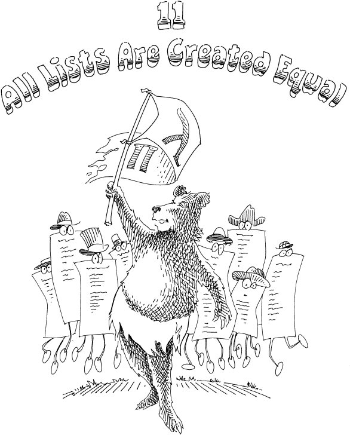

After all that porridge, it’s time for an afternoon coffee break with Swedish treats!

<sup>1</sup>

Yes! *Fika.*

Here is a list of treats for our *fika*.

(**claim *treats***

(Vec Atom 3))

(**define *treats***†

(vec:: **'**kanelbullar

(vec:: **'**plättar

(vec:: **'**prinsesstårta vecnil))))

_______________

†*Kanelbullar* are cinnamon rolls, *plättar* are small pancakes topped with berries, and a *prinsesstårta* is a cake with layers of sponge cake, jam, and custard under a green marzipan surface.

<sup>2</sup>

Sounds great! But how can **treats** be combined with **drinks**?

(**claim *drinks***

(List Atom))

(**define *drinks***

(:: **'**coffee

(:: **'**cocoa nil)))

That’s right—there are some loose ends from the preceding chapter. One loose end is a version of **append** for Vec, and the other is ruling out more foolish definitions of **list→vec**.

<sup>3</sup>

Okay.

If *es* has *ℓ* entries and *end* has *j* entries, then how many entries do they have together?

<sup>4</sup>

Surely they have (**+** *ℓ j*) entries together.

That’s right.

(**claim *vec-append***

(Π ((*E U*)

(*ℓ* Nat)

(*j* Nat))

(→ (Vec *E* *ℓ*) (Vec *E j*)

(Vec *E* (**+** *ℓ j*)))))

<sup>5</sup>

This looks very much like **append**’s type.

How does **vec-append**’s type differ from **append**’s type?

<sup>6</sup>

This more specific type makes clear how many entries are in each list.

Exactly.

To define **vec-append**, what is missing?

<sup>7</sup>

An eliminator for Vec.

Actually, it is possible to define **vec-append** in the same style as **first**, **rest**, **last**, and **drop-last**, using **ind-Nat**, **head**, and **tail**.

The definition that uses **ind-Vec**, however, expresses its intent more directly.

<sup>8</sup>

Can every operation on Vec that can be written using **ind-Nat** also be written using **head** and **tail**?

No.

In all of the definitions that can be written using **head** and **tail**, the type depends only on the length, which is a Nat. Sometimes, though, a type depends on a Vec, and then **ind-Vec** is necessary.

<sup>9</sup>

Is **ind-Vec** like **ind-List**?

Yes, **ind-Vec** is much like **ind-List**. An **ind-Vec**-expression

(**ind-Vec** *n es*

*mot*

*base*

*step*)

has two targets:

1. *n*, which is a Nat,
2. and *es*, which is a (Vec *E n*).

<sup>10</sup>

So *n* is the number of entries in *es*.

Are there any other differences between **ind-List** and **ind-Vec**?

Each part of the **ind-Vec**-expression must account for the number of entries in *es*.

*mot*’s type is

(Π ((*k* Nat))

(→ (Vec *E k*)

*U*))

because it explains why *any* target Nat and Vec are eliminated.

<sup>11</sup>

Why isn’t *E* also an argument in the Π-expression?

Excellent question. This is because the type of entries in a list plays a very different role from the number of entries.

In any individual list, the type of entries is the same throughout, but the number of entries in the **tail** of a list is *different* from the number of entries in the list.

<sup>12</sup>

Why does that matter?

The entry type *E* is determined once, and it is the same for the entire elimination. But the number of entries changes with each of **ind-Vec**’s steps.

How is a motive used for the type of a step?

<sup>13</sup>

The type of a step uses the motive in the type of the almost-answer and the type of the answer.

This means that the motive is used for different numbers of entries. That is why the number of entries is an argument to the motive.

These two varieties of arguments to a type constructor, that either vary or do not vary, have special names. Those that do not vary, such as the entry type in Vec and List, are called *parameters*, and those that do vary are called *indices*.

<sup>14</sup>

So the number of entries in a Vec is an index.

**The Law of ind-Vec**

**If** *n* **is a** Nat**,** *target* **is a (**Vec *E n***),** *mot* **is a**

**(Π ((***k* Nat**))**

**(**→ **(**Vec *E k***)**

*U***))**,

*base* **is a (***mot* zero vecnil**), and** *step* **is a**

**(Π ((***k* Nat**)**

**(***h E***)**

**(***t* **(**Vec *E k***)))**

**(**→ **(***mot k t***)**

**(***mot* **(**add1 *k***) (**vec:: *h t***))))**

**then**

**(ind-Vec** *n target*

*mot*

*base*

*step***)**

**is a (***mot n target***).**

| Yes, it is.† Whenever a type constructor has an index, the index shows up in the motive for its eliminator, and therefore also in the step. _______________ †A family of types whose argument is an inde… | <sup>15</sup> | What is *base*’s type in **ind-Vec**? |
| --- | --- | --- |
| *base*’s type is (*mot* zero vecnil). In **ind-Vec**, *mot* receives two arguments, rather than one. | <sup>16</sup> | Doesn’t **mot-replicate** in frame 10:47 receive two arguments as well? |
| No, though it does appear to. Remember that **mot-replicate** is Curried. Applying **mot-replicate** to its first argument, which is the entry type, constructs a one-argument motive to be used with **… | <sup>17</sup> | What is *step*’s type? |
| *step* transforms an almost-answer for some list *t* into an answer for (vec:: *h t*), so it is a (Π ((*k* Nat) (*h E*) (*t* (Vec *E k*))) (→ (*mot k t*) (*mot* (add1 *k*) (vec:: *h t*)))). Why is *mo… | <sup>18</sup> | The step transforms the almost-answer for *t* into the answer for (vec:: *h t*), which has one more entry than *t*. Why are the **head** and **tail** called *h* and *t*, rather than the usual *e* and … |
| The name *es* is already taken to refer to the second target. Now it is time to use **ind-Vec** to define **vec-append**. Please start the definition. | <sup>19</sup> | Just like **append**, the base is *end*. (**define *vec-append*** (λ (*E ℓ j*) (λ (*es end*) (**ind-Vec** *ℓ es* **mot-vec-append** *end* **step-vec-append**)))) |
| Why is *end*’s type (Vec *E* (**+** *ℓ j*))? | <sup>20</sup> | In the base, *es* is vecnil. This means that the number of entries *ℓ* in *es* is zero, and (**+** zero *j*) is the same Nat as *j*. *end*’s type is (Vec *E j*), which is exactly what we need. |
| Now define **mot-vec-append**. | <sup>21</sup> | The definition can be found by abstracting over the number of entries and the list in the base’s type. (**claim *mot-vec-append*** (Π ((*E U*) (*k* Nat) (*j* Nat)) (→ (Vec *E k*) *U*))) (**define *mot… |
| With **mot-vec-append** in frame 21, **vec-append** would need a λ-expression as its motive. Why? (**define *vec-append*** (λ (*E ℓ j es end*) (**ind-Vec** *ℓ es* (λ (*k*) (**mot-vec-append** E k j)) … | <sup>22</sup> | Because the two arguments to the motive are the two targets, *ℓ* and *es*. But the last two arguments to **mot-vec-append** do not match, so the λ-expression swaps *k* and *j*. |

**The First Commandment of ind-Vec**

**The ind-Vec-expression**

**(****ind-Vec** zero vecnil

*mot*

*base*

*step***)**

**is the same (***mot* zero vecnil**) as** *base***.**

**The Second Commandment of ind-Vec**

**The ind-Vec-expression**

**(ind-Vec (**add1 *n***) (**vec:: *e es***)**

*mot*

*base*

*step***)**

**is the same (***mot* **(**add1 *n***) (**vec:: *e es***)) as**

**(***step n e es*

**(ind-Vec** *n es*

*mot*

*base*

*step***))**.

Consider this definition of **mot-vec-append**, instead.

(**claim *mot-vec-append***

(Π ((*E U*)

(*j* Nat)

(*k* Nat))

(→ (Vec *E k*)

*U*)))

(**define *mot-vec-append***

(λ (*E j k*)

(λ (*es*)

(Vec *E* (**+** *k j*)))))

How does this change **vec-append**?

<sup>23</sup>

The λ-expression for the motive is no longer necessary.

(**define *vec-append***

(λ (*E ℓ j*)

(λ (*es end*)

(**ind-Vec** *ℓ es*

(**mot-vec-append** E j)

*end*

**step-vec-append**))))

When writing a Curried motive, base, or step, it pays to carefully consider the order of arguments.

<sup>24</sup>

It’s certainly easier to re-order **mot-vec-append**’s arguments than it is to write an extra λ-expression.

Now define **step-vec-append**.

What is **step-vec-append**’s type?

<sup>25</sup>

This time, *j* is before *k* in the arguments.

(**claim *step-vec-append***

(Π ((*E U*)

(*j* Nat)

(*k* Nat)

(*e E*)

(*es* (Vec *E k*)))

(→ (**mot-vec-append** E j

*k es*)

(**mot-vec-append** E j

(add1 *k*) (vec:: *e es*)))))

Keen observation.

What is the definition?

<sup>26</sup>

(**define *step-vec-append***

(λ (*E j ℓ-1 e es*)

(λ (*vec-append<sub>es</sub>*)

(vec:: *e vec-append<sub>es</sub>*))))

This use of vec:: is justified because

(**+** (add1 *ℓ**-1*) *j*)

is the same Nat as

(add1 (**+** *ℓ-1 j*)).

All of the pieces of **vec-append** are ready.

<sup>27</sup>

Here is the definition, in a well-earned solid box.

(**define *vec-append***

(λ (*E ℓ j*)

(λ (*es end*)

(**ind-Vec** *ℓ es*

(**mot-vec-append** E j)

*end*

(**step-vec-append** E j)))))

The first loose end has been tied up.

What is a good name for

(**vec-append** Atom 3 2 **treats drinks**)?

<sup>28</sup>

That expression is not described by a type because **drinks** is a (List Atom).

But how about **fika** for this version?

(**claim *fika***

(Vec Atom 5))

(**define *fika***

(**vec-append** Atom 3 2

**treats**

(**list→vec** Atom **drinks**)))

This **fika** is foolish if **list→vec** is foolish. In frame 10:81, a **list→vec** is defined that is foolish, but this foolish definition has the right type.

(**define *step-list→vec***

(λ (*E e es*)

(λ (*list→vec<sub>es</sub>*)

(**replicate** E (**length** es) *e*))))

(**define *list→vec***

(λ (*E es*)

(**ind-List** *es*

*mot-list→vec*

vecnil

(**step-list→vec** E))))

<sup>29</sup>

Using this definition, the normal form of

(**list→vec** Atom **drinks**)

is

(vec:: **'**coffee

(vec:: **'**coffee vecnil)),

but some prefer **'**cocoa to **'**coffee.

How can we rule out this foolishness?

Thus far, we have used more specific types to rule out foolish definitions. Another way to rule out foolish definitions is to *prove* that they are not foolish.†

_______________

†Sometimes, using a more specific type is called an *intrinsic* proof. Similarly, using a separate proof is called *extrinsic*.

<sup>30</sup>

What is an example of such a proof?

One way to rule out foolish definitions of **list→vec** is to prove that transforming the Vec back into a List results in an equal List.

This requires **vec→list**. Here is the motive.

(**claim *mot-vec→list***

(Π ((*E U*)

(*ℓ* Nat))

(→ (Vec *E* *ℓ*)

*U*)))

(**define *mot-vec→list***

(λ (*E ℓ*)

(λ (*es*)

(List *E*))))

What is the step?

<sup>31</sup>

The step replaces each vec:: with a :: constructor, just as **step-list→vec** replaces each :: with a vec:: constructor.

(**claim *step-vec→list***

(Π ((*E U*)

(*ℓ**-1* Nat)

(*e E*)

(*es* (Vec *E* *ℓ**-1*)))

(→ (**mot-vec→list** E

*ℓ**-1 es*)

(**mot-vec→list** E

(add1 *ℓ**-1*) (vec:: *e es*)))))

(**define *step-vec→list***

(λ (*E ℓ-1 e es*)

(λ (*vec→list<sub>es</sub>*)

(:: *e vec→list<sub>es</sub>*))))

The definition of **vec→list** is also very similar to the definition of **list→vec**.

(**claim *vec→list***

(Π ((*E U*)

(*ℓ* Nat))

(→ (Vec *E* *ℓ*)

(List *E*))))

(**define *vec→list***

(λ (*E ℓ*)

(λ (*es*)

(**ind-Vec** *ℓ es*

(**mot-vec→list** E)

nil

(**step-vec→list** E)))))

What is the normal form of

(**vec→list** Atom 3 **treats**)?

<sup>32</sup>

It is

(:: **'**kanelbullar

(:: **'**plättar

(:: **'**prinsesstårta nil))).

So is it clear how to find the value of an **ind-Vec**-expression?

<sup>33</sup>

Yes, it is just like finding the value of an **ind-List**-expression, except the step is applied to both targets.

How can the statement,

“For every List, transforming it into a Vec and back to a List yields a list that is equal to the starting list.”

be written as a type?

<sup>34</sup>

The term *every* implies that there should be a Π. How about this type?

(**claim *list→vec→list=***

(Π ((*E U*)

(*es* (List *E*)))

(**=** (List *E*)

*es*

(**vec→list** E

(**list→vec** E es)))))

That is very close, but the second argument to **vec→list** is the number of entries in the Vec.

How many entries does

(**list→vec** E es)

have?

<sup>35</sup>

Oh, right, can’t forget the **length**.

(**claim *list→vec→list=***

(Π ((*E U*)

(*es* (List *E*)))

(**=** (List *E*)

*es*

(**vec→list** E

(**length** E es)

(**list→vec** E es)))))

What is an appropriate target for induction?

<sup>36</sup>

The target of induction is *es*. The definition has the usual suspects: a motive, a base, and a step.

(**define *list→vec→list=***

(λ (*E es*)

(**ind-List** *es*

(**mot-list→vec→list=** E)

(**base-list→vec→list=** E)

(**step-list→vec→list=** E))))

What is the base?

<sup>37</sup>

The base’s type is

(**=** (List *E*)

nil

(**vec→list** E

(**length** E nil)

(**list→vec** E nil))),

also known as

(**=** (List *E*) nil nil).

That is the base’s type.

But what is the base?

<sup>38</sup>

(same nil), of course.

Once again, there’s no need to define

**base-list→vec→list=**.

Here is the motive’s type.

(**claim *mot-list*→*vec*→*list*=**

(Π ((*E U*))

(→ (List *E*)

*U*)))

Define **mot-list→vec→list=.**

<sup>39</sup>

Abstracting over nil in the base’s type in frame 37 leads directly to the definition.

(**define *mot-list→vec→list=***

(λ (*E es*)

(**=** (List *E*)

*es*

(**vec→list** E

(**length** E es)

(**list→vec** E es)))))

The only thing left is the step.

What is an appropriate type for the step?

<sup>40</sup>

Follow the Law of **ind-List**.

(**claim *step-list→vec→list=***

(Π ((*E U*)

(*e E*)

(*es* (List *E*)))

(→ (**mot-list→vec→list=** E

*es*)

(**mot-list→vec→list=** E

(:: *e es*)))))

Here is the beginning of a definition.

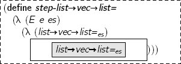

What can be put in the box to transform the almost-proof for *es* into a proof for (:: *e es*)?

<sup>41</sup>

The almost-proof, *list→vec→list=<sub>es</sub>*, is an

(**=** (List *E*)

*es*

(**vec→list** E

(**length** E es)

(**list→vec** E es))).

This is an opportunity to use our old friend **cong** from chapter 8 to eliminate *list→vec→list=<sub>es</sub>*.

Remember, **cong** expresses that every function produces equal values from equal arguments.

<sup>42</sup>

Equal in, equal out!

How would we use **cong** here?

What is the type of

(**cong** (same **'**plättar)

(**snoc** Atom (:: **'**kanelbullar nil)))?

<sup>43</sup>

**snoc** does not yet have the new entry to be placed at the end of the list.

Because

(same **'**plättar)

is an

(**=** Atom **'**plättar **'**plättar),

and that new entry will be **'**plättar, so the type is

(**=** (List Atom)

(:: **'**kanelbullar

(:: **'**plättar nil))

(:: **'**kanelbullar

(:: **'**plättar nil))).

Prove that

“consing **'**plättar onto two equal lists of treats produces equal lists of treats.”

<sup>44</sup>

This proof can be used in the box.

First, how can the statement be written as a type?

<sup>45</sup>

“Two equal lists of treats” can be written as a Π-expression with two (List Atom) arguments and a proof that they are equal.

(**claim *Treat-Statement***

*U*)

(**define *Treat-Statement***

(Π ((*some-treats* (List Atom))

(*more-treats* (List Atom)))

(→ (**=** (List Atom)

*some-treats*

*more-treats*)

(**=** (List Atom)

(:: **'**plättar *some-treats*)

(:: **'**plättar *more-treats*)))))

Proving this statement is easier with this definition.

(**claim *::-plättar***

(→ (List Atom)

(List Atom)))

(**define *::-plättar***

(λ (*tasty-treats*)

(:: **'**plättar *tasty-treats*)))

Use this with **cong** to prove **Treat-Statement**.

<sup>46</sup>

Here is the definition of **treat-proof**.

(**claim *treat-proof***

*Treat-Statement*)

(**define *treat-proof***

(λ (*some-treats more-treats*)

(λ (*treats=*)

(**cong** *treats= **::-plättar***))))

Great!

What can be said about the lengths of equal lists?

<sup>47</sup>

Every two equal lists have equal lengths.

Now prove that

“Every two equal treat lists have equal lengths.”

using **cong**.

<sup>48</sup>

**length-treats=** is similar to **treat-proof**.

(**claim *length-treats=***

(Π ((*some-treats* (List Atom))

(*more-treats* (List Atom)))

(→ (**=** (List Atom)

*some-treats*

*more-treats*)

(**=** Nat

(**length** Atom *some-treats*)

(**length** Atom *more-treats*)))))

(**define *length-treats=***

(λ (*some-treats more-treats*)

(λ (*treats=*)

(**cong** *treats=* (**length** Atom)))))

Returning to the matter at hand, it is now possible to fill the box in frame 41 with a **cong**-expression.

The almost-proof, *list→vec→list=<sub>es</sub>*, is an

(**=** (List *E*)

*es*

(**vec→list** E

(**length** E es)

(**list→vec** E es))).

What is the box’s type in frame 41?

<sup>49</sup>

The box’s type is

(**=** (List *E*)

(:: *e es*)

(**vec→list** E

(**length** E (:: *e es*))

(**list→vec** E (:: *e es*)))).

Now it is time for an observation about **list→vec**, similar to the observation about **+** on page 210.

Let’s see.

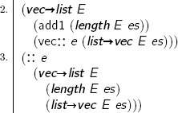

**When in Doubt, Evaluate**

**Gain insight by finding the values of expressions in types and working out examples in “same-as” charts.**

| How is this new observation similar to the observation about **+**? | <sup>51</sup> | The preceding observation is that we can pull out an add1 from **+**’s first argument and put the add1 around the whole expression. This new observation is that we can similarly pull out a :: from **l… |
| --- | --- | --- |
| When using **cong**, the same function is applied to both the FROM and the TO of an **=**-expression. What function transforms *es* into (:: *e es*) and (**vec→list** E (**length** E es) (**list→vec**… | <sup>52</sup> | (:: *e*), right? |
| That is very close. But the constructor of functions is λ. Other constructors construct different types. | <sup>53</sup> | Here is a function that does the trick. (**claim *::-fun*** (Π ((*E U*)) (→ *E* (List *E*) (List *E*)))) (**define *::-fun*** (λ (*E*) (λ (*e es*) (:: *e es*)))) |
| Now complete the box in frame 41 to define **step-list→vec→list=**. | <sup>54</sup> | Here it is. (**define *step-list→vec→list=*** (λ (*E e es*) (λ (*list→vec→list=<sub>es</sub>*) (**cong** *list→vec→list=<sub>es</sub>* (**::-fun** E e))))) |
| It’s time to put the pieces together, using the motive, the base, and the step. Remember the **claim** in frame 35 on page 255. | <sup>55</sup> | Here is another well-built solid box. (**define *list→vec→list=*** (λ (*E es*) (**ind-List** *es* (**mot-list→vec→list=** E) (same nil) (**step-list→vec→vec→list=** E)))) |
| This proof rules out the foolish definition from frame 29 on page 253. Why? | <sup>56</sup> | Because, using the foolish definition, (**vec→list** Atom (**length** Atom **drinks**) (**list→vec** Atom **drinks**)), is not equal to **drinks**. |
| Why not? | <sup>57</sup> | Because (:: **'**coffee (:: **'**coffee nil)) is not equal to (:: **'**coffee (:: **'**cocoa nil)). |
| Where would the proof go wrong? | <sup>58</sup> | It would go wrong in frame 54 because the new observation in frame 50 would no longer be the case. |
| Exactly. This proof has ruled out many foolish definitions. | <sup>59</sup> | Many? |
| At some point, it becomes necessary to trust that enough specific types have been used to avoid the foolishness one might be prone to. This requires hard-won self-knowledge. If **vec→list** could remo… | <sup>60</sup> | How could that be? |
| Imagine that **vec→list** and **list→vec** both reversed the order of the list. | <sup>61</sup> | Coffee and cake are good for the imagination. |
| In this imaginary world, the proof would work, but both **vec→list** and **list→vec** would be foolish. | <sup>62</sup> | If they also reversed lists, then that should have been part of their names! |

**Now, go and enjoy a cozy *fika***